# Projet 2: Value at Risk des rendements logarithmiques de l’action Schneider Electric suivi de Backtesting pour vérifier la précision de cette estimation

BAILLET Benjamin

2024-11-13

# **Résultats obtenus**

Le **meilleur modèle** pour notre série est un **ARMA(0,5)-APARCH(1,1) avec un distribution nig et delta=1, ma3=0, mu=0, ma1=0**

| Méthode d’estimation de la VaR | Var estimée | Nombre de violations théorique | Nombre de violations empirique | P-value du test de Kupiec | P-value du test de Christoffersen |
| --- | --- | --- | --- | --- | --- |
| VaR Paramétrique |  | 62,5 | 62 | 0.948 | 0.275 |
| VaR Normale | 2.911399% | 62 | 66 | 0.6572287 | 0.07030575 |
| VaR de Cornish-Fisher | 2.844005% | 62 | 67 | 0.5680130 | 0.07719156 |
| VaR Historique | 2.961336% | 62 | 65 | 0.7520836 | 0.06263415 |

**En moyenne la VaR paramétrique est de 2.82% environ sur rtt**.

# **Introduction**

**Ce projet vise à évaluer la Value at Risk de l’action Schneider Electric. Puis par le biais du backtesting, nous vérifierons la précision de cette estimation.**

```r
my_ticker <- 'SU.PA'
first_date <- "2010-01-04"
last_date <-"2024-11-13"

# fetch data
df_yf <- yf_get(tickers = my_ticker,
                first_date = first_date,
                last_date = last_date,
                freq_data='daily',type_return='log')

pt<-df_yf$price_adjusted
dpt=diff(pt)
rt=df_yf$ret_adjusted_prices[-1]

N<-length(rt)

datesp<-df_yf$ref_date
dates<-datesp[-1]

# dates[2555] => 31/12/2019 = dernière date de 2019
# dates[2556]  => 02/01/2020 = première date de 2020

rte=rt[1:2555] #rt sur l'ensemble d'estimation de 2010 à 2019 inclus
rtt=rt[2556:N] #rt sur l'ensemble de test de 2020 à 2024 inclus

T<-length(rte)  #nombre d'observations dans l'ensemble d'estimation
Q<-length(rtt)  #nombre d'observations dans l'ensemble de test

datesp<-df_yf$ref_date
dates<-datesp[-1] # -1 pour la première valeur manquante
```

## **Notations**

- VaR: Value at Risk
- $p_t$ : le cours de l’action Schneider Electric à la date t (qui est un jour ouvré à la bourse)
- $dp_t = p_t - p_{t-1}$ : les variations du cours de Bourse de l’action Schneider Electric
- $r_t=log(p_t)-log(p_{t-1})$ : le rendement logarithmique de l’action  
  On sépare les données en deux ensembles $r_{tt}$ et $r_{te}$ contenant des années complètes et de telle sorte que le premier comprend environ 2/3 des données les plus vieilles (2010-2019) et le deuxième 1/3 des données les plus récentes (2020- novembre 2024):
- $r_{te}$ : ensemble d’estimation : 04/01/2010 - 31/12/2019
- $r_{tt}$ : ensemble de test : 02/01/2020 - 13/11/2024

## **Chronogramme**

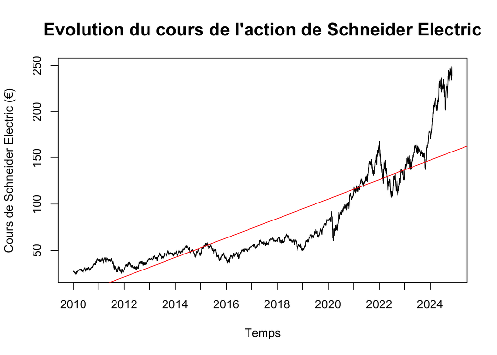

```r
datesp<-df_yf$ref_date
first_day_of_year = NULL
for (i in 1:15) {
  first_day_of_year[i] = as.character(datesp[format(datesp, "%Y") == 2009+i][1])
}

plot(datesp, pt, type='l', ylab="Cours de Schneider Electric (€)", xlab="Temps", cex.main=1.5, main="Evolution du cours de l'action de Schneider Electric", xaxt = "n")

axis(side = 1, at=as.Date(first_day_of_year), labels=format(as.Date(first_day_of_year), "%Y"))

fit0 = lm(pt ~ datesp)
abline(fit0, col="red")
```

## **Problématiques**

Nous chercherons à identifier la distribution appropriée pour nos aléas, en utilisant un modèle ARMA-GARCH pour modéliser de manière optimale la moyenne conditionnelle et la volatilité conditionnelle. Ensuite, nous évaluerons la performance de ce modèle à travers le backtesting, afin de garantir une estimation correcte de la Value at Risk paramétrique. Enfin, nous nous intéresserons à la VaR normale, la VaR de Cornish-Fisher, ainsi que la VaR historique.

## **ARMA-GARCH**

### **Modèle ARMA**

**AR** :

Un modèle AR(p) (autorégressif d’ordre p) s’écrit :

$$X_t = c +\sum_{i=1}^p \phi_iX_{t-i}
+\varepsilon_t$$

avec :  
$\phi_1,\dots,\phi_p$: les paramètres du modèle ;  
$c$: une constante ;  
$\varepsilon_t$: un bruit blanc.

**MA** :

Un modèle MA(q) (moving average ou moyenne mobile d’ordre q) s’écrit :

$$X_t=\varepsilon_t +
\sum_{i=1}^q\theta_i\varepsilon_{t-i}$$

avec :  
$\theta_i,\dots,\theta_q$: les paramètres du modèle ;  
$\varepsilon_t,\varepsilon_{t-1}, \dots, \varepsilon_q$: des termes d’erreurs. Ces derniers sont supposés indépendants et identiquements distribués selon une loi normale de moyenne nulle.

**ARMA** :

Un modèle ARMA(p,q) est un modèle autorégressif et moyenne mobile d’ordre (p,q) :

$$X_t=\varepsilon_t+\sum_{i=1}^p \phi_i
X_{t-i} + \sum_{i=1}^q \theta_i \varepsilon_{t-i}$$

Nous allons dans un premier temps travailler sur un modèle ARMA(1,1) et si celui-ci ne permet pas de prendre en compte l’autocorrélation des aléas, nous passerons au modèle ARMA(0,5) obtenu dans le projet 1.

### **Modèle GARCH**

Le modèle autorégressif conditionnellement hétéroscédastique généralisé (GARCH) permet de capter le comportement de la volatilité dans le temps.

Nous allons étudier **6 modèles GARCH** pour trouver celui qui est le plus adapté à nos données. Nous allons tester un par un les modèles en choisissant une distribution appropriée pour nos données. Nous n’allons pas prendre en compte la saisonnalité car dans le projet 1 nous n’avons vu qu’il n’y en a ni pour $rt_e$ ni pour $rt_t$.

On partira, pour chacun des modèles, d’un GARCH(m,s) avec $m=s=1$.

# **Modèle ARMA GARCH**

On va, dans un premier temps trouver la distribution la plus adaptée à nos données $r_{te}$.

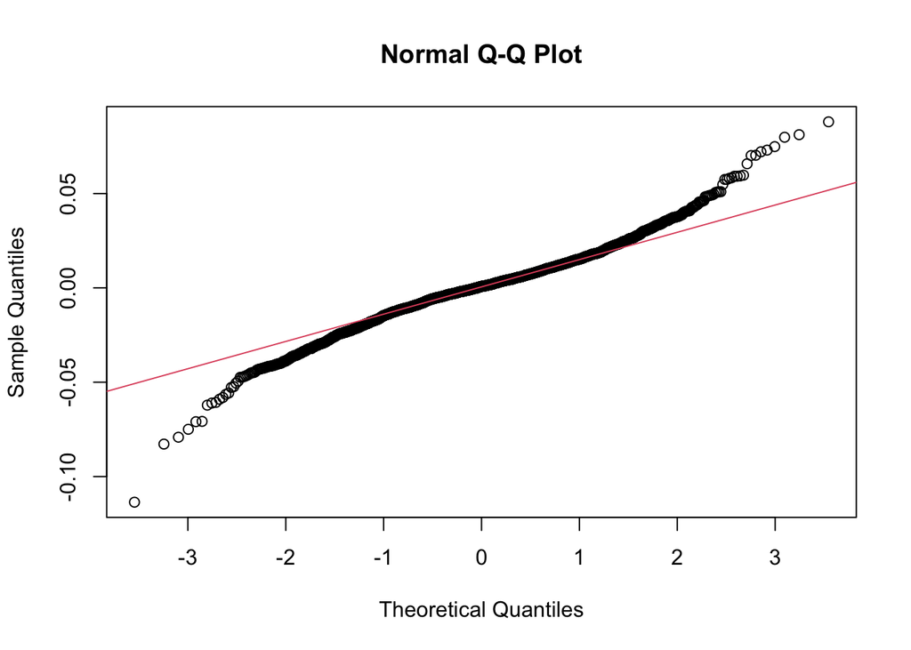

```r
qqnorm(rte)
qqline(rte, col = 2)
```

La majorité des points se trouvent proches de la ligne rouge (la ligne de référence pour une distribution normale). Cela suggère que les données observées suivent en grande partie une distribution normale. Cependant, on voit sur le graphique à quel point les queues de la distribution sont éloignées de la normale en rouge. On retrouve le résultat trouvé dans le projet 1, c’est à dire des queues de distribution épaisses.

On va donc s’intéresser à des distributions à queues épaisses et asymétriques (résultat du projet 1) :

- Student asymétrique **(sstd)**
- Gaussienne inverse asymétrique **(nig)**
- Hyperbolique asymétrique **(hyp)**
- Hyperbolique généralisée asymétrique **(ghyp)**
- Hyperbolique généralisée skew t **(ghst)**

```r
# estimation distribution normale
fitn<-fit.gaussuv(data=rte)
summary(fitn)
```

```
## Gaussian Distribution:
##
## Parameters:
##           mu        sigma
## 0.0004276908 0.0179548432
##
## Call:
## fit.gaussuv(data = rte)
##
## Optimization information:
## log-Likelihood:                6645.945
## AIC:                           -13287.89
## Fitted parameters:             mu, sigma;  (Number: 2)
## Number of iterations:          0
## Converged:                     TRUE
```

```r
# estimation student asymtrique
fitstu<-fit.tuv(rte,silent=T)
summary(fitstu)
```

```
## Asymmetric Student-t Distribution:
##
## Parameters:
##            nu            mu         sigma         gamma
##  4.1966378640  0.0010485143  0.0184934709 -0.0006342893
##
## Call:
## fit.tuv(data = rte, silent = T)
##
## Optimization information:
## log-Likelihood:                6757.398
## AIC:                           -13506.8
## Fitted parameters:             lambda, mu, sigma, gamma;  (Number: 4)
## Number of iterations:          209
## Converged:                     TRUE
```

```r
# gaussienne inverse asymétrique
fitnig<-fit.NIGuv(data=rte,silent=T)
summary(fitnig)
```

```
## Asymmetric Normal Inverse Gaussian Distribution:
##
## Parameters:
##     alpha.bar            mu         sigma         gamma
##  0.9193979665  0.0012280266  0.0180576933 -0.0008018096
##
## Call:
## fit.NIGuv(data = rte, silent = T)
##
## Optimization information:
## log-Likelihood:                6764.369
## AIC:                           -13520.74
## Fitted parameters:             alpha.bar, mu, sigma, gamma;  (Number: 4)
## Number of iterations:          171
## Converged:                     TRUE
```

```r
# hyperbolique asymétrique
fithyp<-fit.hypuv(rte,silent=T)
summary(fithyp)
```

```
## Asymmetric Hyperbolic Distribution:
##
## Parameters:
##     alpha.bar            mu         sigma         gamma
##  0.4465432385  0.0012346475  0.0179747629 -0.0008070091
##
## Call:
## fit.hypuv(data = rte, silent = T)
##
## Optimization information:
## log-Likelihood:                6768.192
## AIC:                           -13528.38
## Fitted parameters:             alpha.bar, mu, sigma, gamma;  (Number: 4)
## Number of iterations:          197
## Converged:                     TRUE
```

```r
# hyperbolique généralisée asymétrique
fitghypuv<-fit.ghypuv(rte,silent=T)
summary(fitghypuv)
```

```
## Asymmetric Generalized Hyperbolic Distribution:
##
## Parameters:
##        lambda     alpha.bar            mu         sigma         gamma
##  1.0859685676  0.3842097132  0.0012136383  0.0179531069 -0.0007836602
##
## Call:
## fit.ghypuv(data = rte, silent = T)
##
## Optimization information:
## log-Likelihood:                6768.287
## AIC:                           -13526.57
## Fitted parameters:             lambda, alpha.bar, mu, sigma, gamma;  (Number: 5)
## Number of iterations:          212
## Converged:                     TRUE
```

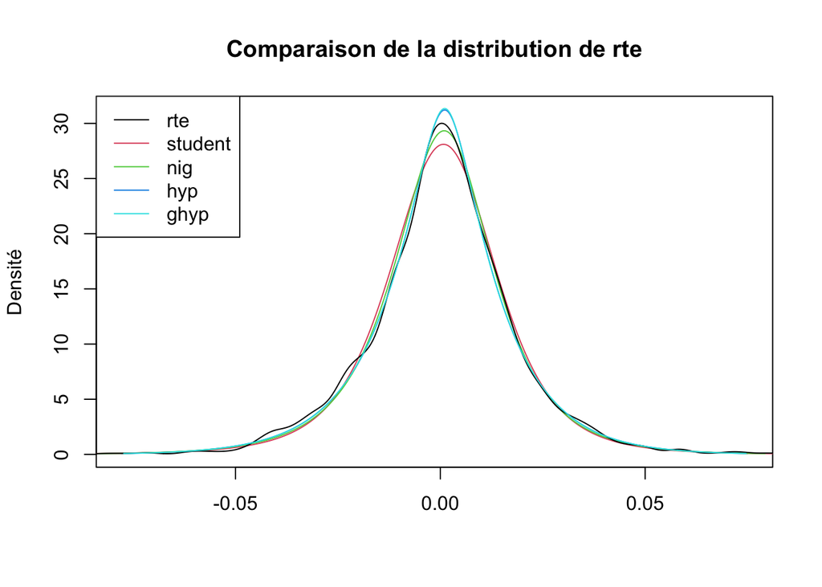

```r
plot(fithyp,col=4, type='l', ylab="Densité", xlab="")
lines(fitstu,col=2) #student
lines(fitnig,col=3) # estimateur de la densité de rte
lines(density(rte),col=1)
lines(fitghypuv,col=5)

legend("topleft",legend =c("rte","student","nig","hyp","ghyp"), col =1:5,lty=rep(1,5))
title(main="Comparaison de la distribution de rte")
```

Parmi toutes les distributions, c’est la **nig** qui se rapproche le plus de celle de rte.

```r
ghstfit<-skewhypFit(rte, print = FALSE, plot =FALSE, hessian = TRUE)
summary(ghstfit)
```

```
##
## Data:
## Parameter estimates:
##         mu          delta          beta           nu
##     0.0010528     0.0274047    -1.8561144     4.1963880
##   ( 0.0006048)  ( 0.0018801)  ( 2.1092308)  ( 0.3935810)
## Likelihood:         6757.398
## Method:             Nelder-Mead
## Convergence code:   0
## Iterations:         243
```

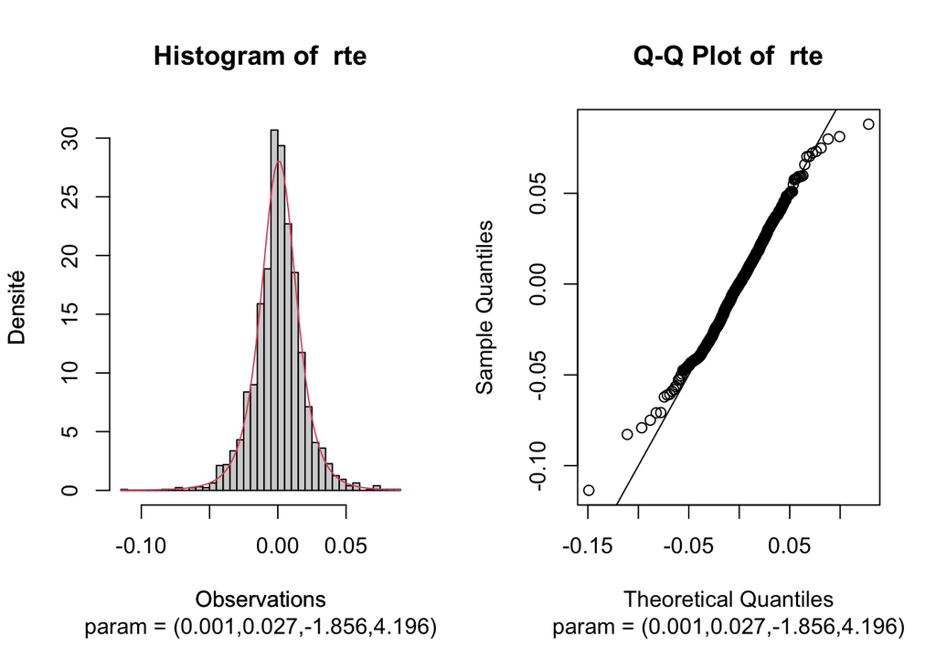

```r
ghstfit<-skewhypFit(rte, print = FALSE, plot =FALSE, hessian = TRUE)

op <- par(mfrow = c(1,2))
plot(ghstfit, which = 1, xlab="Observations", ylab="Densité")
plot(ghstfit, which = 3)
```

```r
par(op)
```

La distribution Hyperbolique généralisée skew t (ghst) semble également être adaptée. On va tester la **gaussienne inverse asymétrique (nig)** ainsi que la distribution **hyperbolique généralisée skew t (ghst)** avec les différents modèles GARCH afin de retenir la meilleure distribution.

On prendra en compte les deux distributions quand testera les modèles GARCH :

## **Les tests et les hypothèses des modèles GARCH**

| Test | Statistique | Hypothèse | Distribution sous $H_0$ | Règle de décision |
| --- | --- | --- | --- | --- |
| Significativité des coefficients sur les *Robust Standard Errors* | **t de Student** $t=\frac{\|m(e)\|}{\sigma_e} \times \sqrt{T}$ avec : T: le nombre d’observations ; $m(e)$: la moyenne des résidus de la régression ; $\sigma_e$: l’écart type des résidus ; | $H_0$ : le coefficient est significatif dans la régression $H_a$ : le coefficient n’est pas significatif | $t \sim N(0,1)$ | On accepte lorsque la p-value est supérieure à 5% |
| Autocorrélation des aléas | **Ljung-Box** $Q_K = T \times (T+2) \sum_{k=1}^{K} \frac{\hat \rho (k)^2}{T-K}$ avec T, le nombre d’observations | $H_0:\rho_1=\rho_2=\rho_3=...=\rho_k\rightarrow$ Absence d’autocorrélation jusqu’à l’ordre k $H_a$ : au moins un $\rho_i \ne 0$ $\rightarrow$ Présence d’autocorrélation | $Q_K \underset{T\to +\infty}\longrightarrow \chi^2$ | On accepte lorsque la p-value est supérieure à 5% |
| Homoscédasticité conditionnelle des aléas | **Engle** Estimer $\varepsilon_t$ par MCO $e_t^2 = a+c_1e_{t-1}^2+c_2e_{t-2}^2 + \dots + c_pe_{t-p}^2 + erreur_t$ statistique : $LM = T \times R^2$ avec $R^2$ le coefficient de détermination associé à… | $H_{0}:\alpha_{1}=\alpha_{2}=\dots=\alpha_{P}=0$ : pas d’effets ARCH et homoscédasticité conditionnelle $H_{a}:\alpha_{i}\ne0\;avec\;i\ne0$ : présence d’effets ARCH et hétéroscédasticité conditionnell… | $LM \sim \chi^2(p)$ | On accepte lorsque la p-value est supérieure à 5% |
| Stabilité individuelle et jointe des paramètres du modèle dans le temps | **Nyblom** | $H_{0}$ : le paramètre est stable dans le temps $H_{a}$ : le paramètre varie dans le temps |  | On accepte lorsque la valeur estimée du paramètre est inférieure à la valeur tabulée (à 5%) |
| Effet de levier | **Sign Bias Test d’Engle et Ng** Estimer $\tilde v_t^2 = c_0+c_1I_{\tilde v_{t-1}<0}+c_2I_{\tilde v_{t-1}<0}\tilde v_{t-1}+c_3I_{\tilde v_{t-1}\ge0}\tilde v_{t-1}+u_t$ et on testera la nullité de $c_1… | On a respectivement 4 hypothèses : $H_{0}:c_1=0$ : pas d’effet signe $H_{0}:c_2=0$ : pas d’effet taille d’un choc < 0 $H_{0}:c_3=0$ : pas d’effet taille d’un choc > 0 $H_{0}:c_1=c_2=c_3=0$ : pas d’eff… | $t \sim N(0,1)$ | On accepte lorsque la p-value est supérieure à 5% |
| Adjusted Pearson Goodness of fit test | **Pearson** | $H_0$ : adéquation des 2 distributions $H_a$ : les 2 distributions ne sont pas en adéquation |  | On accepte lorsque p-values sont supérieures à 5% |

**Procédure**: On regarde les pvalues dans Robust Standard Errors et lorsqu’il y a des pvalues > 5% (excepté celle de $\alpha_0$ dont on tient pas compte si $\alpha_0$ > 0), on supprime le coefficient donc la pvalue est la plus élevée et on s’arrête lorsqu’on ne peut plus enlever de coefficients (shape et skew ne peuvent pas être retirés par exemple) ou lorsque toutes les pvalues sont inférieures à 5% ou lorsque $\alpha_0$ vaut 0.

- Quand toutes les pvalues sont inférieures à 5%, le modèle est correct.
- Quand toutes les pvalues sont inférieures à 5% sauf skew et/ou shape, le modèle est incorrect.
- Quand toutes les pvalues sont inférieures à 5% et que $\alpha_0$ vaut 0, le modèle est incorrect car il faut que $\alpha_0$ soit stictement supérieur à 0.

**Dans cette partie on garde uniquement la dernière spécification et toutes les autres testées ont été mises en annexe.**

## **APARCH**

Nous allons commencer par estimer un modèle APARCH sur les deux distributions précédentes que l’on veut tester et les comparer pour trouver la meilleure. Nous choisirons celle qui a le plus grand nombre de p-values > 5% dans le test de Pearson.

Un processus $v_t$ satisfait une représentation APARCH(m,s) ssi :

$r_t = \mu+v_t$

$v_t=\sigma_t\varepsilon_t$

$$\sigma_t^\delta=\alpha_0+\sum_{i=1}^m\alpha_i(\vert
v_{t-i}\vert
-\gamma_iv_{t-i})^\delta+\sum_{j=1}^s\beta_j\sigma_{t-j}^\delta$$

avec :  
$\alpha_0 \gt 0$  
$\alpha_i \ge 0 \ \forall i \in \{1,\dots,m\}$ $  
$-1 \lt \gamma_i \lt 1 \ \forall i \in \{1,\dots,m\}$  
$\beta_j \ge 0 \ \forall j \in \{1,\dots,s\}$  
$\delta \gt 0$ et plus spécifiquement $\delta \in \{1,2\}$

### **Gaussienne inverse asymétrique**

```r
spec1 = ugarchspec(variance.model=list(model="apARCH", garchOrder=c(1,1)),
                   mean.model=list(armaOrder=c(0,5)),distribution.model="nig",fixed.pars=list(delta=1, ma3=0, mu=0,  ma1=0))
fit1= ugarchfit(spec = spec1,data = rt,out.sample=length(rtt),solver="hybrid")
show(fit1)
```

```
##
## *---------------------------------*
## *          GARCH Model Fit        *
## *---------------------------------*
##
## Conditional Variance Dynamics
## -----------------------------------
## GARCH Model  : apARCH(1,1)
## Mean Model   : ARFIMA(0,0,5)
## Distribution : nig
##
## Optimal Parameters
## ------------------------------------
##         Estimate  Std. Error  t value Pr(>|t|)
## mu      0.000000          NA       NA       NA
## ma1     0.000000          NA       NA       NA
## ma2    -0.036509    0.019548  -1.8676 0.061812
## ma3     0.000000          NA       NA       NA
## ma4    -0.038093    0.019686  -1.9351 0.052979
## ma5    -0.047673    0.017653  -2.7006 0.006921
## omega   0.000187    0.000041   4.6090 0.000004
## alpha1  0.045099    0.004071  11.0774 0.000000
## beta1   0.956213    0.002586 369.7983 0.000000
## gamma1  0.955893    0.154144   6.2013 0.000000
## delta   1.000000          NA       NA       NA
## skew   -0.128914    0.039036  -3.3024 0.000959
## shape   2.257377    0.438738   5.1452 0.000000
##
## Robust Standard Errors:
##         Estimate  Std. Error   t value Pr(>|t|)
## mu      0.000000          NA        NA       NA
## ma1     0.000000          NA        NA       NA
## ma2    -0.036509    0.020168   -1.8102 0.070258
## ma3     0.000000          NA        NA       NA
## ma4    -0.038093    0.020252   -1.8810 0.059977
## ma5    -0.047673    0.016398   -2.9073 0.003646
## omega   0.000187    0.000040    4.6710 0.000003
## alpha1  0.045099    0.003234   13.9445 0.000000
## beta1   0.956213    0.000888 1077.0133 0.000000
## gamma1  0.955893    0.143823    6.6463 0.000000
```

[output cut: 60 more lines]

```
## Negative Sign Bias 0.25151 0.8014
## Positive Sign Bias 0.08099 0.9355
## Joint Effect       0.38584 0.9432
##
##
## Adjusted Pearson Goodness-of-Fit Test:
## ------------------------------------
##   group statistic p-value(g-1)
## 1    20     26.61      0.11401
## 2    30     39.81      0.08715
## 3    40     50.64      0.10040
## 4    50     66.51      0.04858
##
##
## Elapsed time : 3.021699
```

Son BIC vaut **-5.3947**.

### **Hyperbolique généralisée skew t**

```r
spec1 = ugarchspec(variance.model=list(model="apARCH", garchOrder=c(1,1)),
                   mean.model=list(armaOrder=c(0,5)),distribution.model="ghst", fixed.pars=list(delta=1,  ma3=0, ma1=0))
fit1= ugarchfit(spec = spec1,data = rt,out.sample=length(rtt),solver="hybrid")
show(fit1)
```

```
##
## *---------------------------------*
## *          GARCH Model Fit        *
## *---------------------------------*
##
## Conditional Variance Dynamics
## -----------------------------------
## GARCH Model  : apARCH(1,1)
## Mean Model   : ARFIMA(0,0,5)
## Distribution : ghst
##
## Optimal Parameters
## ------------------------------------
##         Estimate  Std. Error  t value Pr(>|t|)
## mu      0.000149    0.000265   0.5632 0.573300
## ma1     0.000000          NA       NA       NA
## ma2    -0.035424    0.019710  -1.7973 0.072290
## ma3     0.000000          NA       NA       NA
## ma4    -0.037734    0.019862  -1.8998 0.057454
## ma5    -0.048519    0.019060  -2.5456 0.010908
## omega   0.000171    0.000041   4.1842 0.000029
## alpha1  0.044780    0.003934  11.3833 0.000000
## beta1   0.957051    0.002403 398.2753 0.000000
## gamma1  0.961623    0.153963   6.2458 0.000000
## delta   1.000000          NA       NA       NA
## skew   -0.432969    0.188754  -2.2938 0.021801
## shape   7.692347    1.142331   6.7339 0.000000
##
## Robust Standard Errors:
##         Estimate  Std. Error    t value Pr(>|t|)
## mu      0.000149    0.000265    0.56136 0.574550
## ma1     0.000000          NA         NA       NA
## ma2    -0.035424    0.020353   -1.74048 0.081775
## ma3     0.000000          NA         NA       NA
## ma4    -0.037734    0.020215   -1.86666 0.061949
## ma5    -0.048519    0.018843   -2.57496 0.010025
## omega   0.000171    0.000041    4.20353 0.000026
## alpha1  0.044780    0.003182   14.07114 0.000000
## beta1   0.957051    0.000812 1179.26992 0.000000
## gamma1  0.961623    0.144988    6.63244 0.000000
```

[output cut: 61 more lines]

```
## Negative Sign Bias 0.37544 0.7074
## Positive Sign Bias 0.15610 0.8760
## Joint Effect       0.37797 0.9448
##
##
## Adjusted Pearson Goodness-of-Fit Test:
## ------------------------------------
##   group statistic p-value(g-1)
## 1    20     27.44     0.094766
## 2    30     51.31     0.006496
## 3    40     54.64     0.049334
## 4    50     53.83     0.294870
##
##
## Elapsed time : 5.299023
```

## **GJR-GARCH**

$$r_t = \mu +v_t \qquad
v_t=\sigma_t\varepsilon_t \\ \sigma_t^2 = \alpha_0
+\sum_{i=1}^m(\alpha_iv_{t-i}^2 + \gamma_i I_{t-i \lt0}v_{y-i}^2) +
\sum_{j=1}^s \beta_j \sigma_{t-j}^2$$
.

où $\varepsilon_t$ sont des bruits blancs et $I_{t-i} = 1$ si $v_{t-i \lt 0}$ et 0 sinon.  
et :  
$\alpha_0 \gt 0$  
$\alpha_i \ge 0 \ \forall i \in \{1,\dots,m\}$ $  
$\beta_j \ge 0 \ \forall j \in \{1,\dots,s\}$

Dans le cas d’un GJR-GARCH(1,1) :

$$\sigma_t^2=
\left\{{\alpha_0+(\alpha_1+\gamma)v_{t-1}^2 +\beta_1\sigma_{t-1}^2
\text{si} \varepsilon_{t-1}\le0\atop \alpha_0+\alpha_1v_{t-1}^2
+\beta_1\sigma_{t-1}^2 \text{ sinon}}\right.$$

### **Gaussienne inverse asymétrique**

```r
spec2 = ugarchspec(variance.model=list(model="gjrGARCH", garchOrder=c(1,1)),
                   mean.model=list(armaOrder=c(1,1)),distribution.model="nig",fixed.pars=list(alpha1=0,gamma1=0,mu=0))
fit2= ugarchfit(spec = spec2,data = rt,out.sample=length(rtt),solver="hybrid")
show(fit2)
```

```
##
## *---------------------------------*
## *          GARCH Model Fit        *
## *---------------------------------*
##
## Conditional Variance Dynamics
## -----------------------------------
## GARCH Model  : gjrGARCH(1,1)
## Mean Model   : ARFIMA(1,0,1)
## Distribution : nig
##
## Optimal Parameters
## ------------------------------------
##         Estimate  Std. Error    t value Pr(>|t|)
## mu      0.000000          NA         NA       NA
## ar1     0.777586    0.104421    7.44662 0.000000
## ma1    -0.819178    0.095421   -8.58487 0.000000
## omega   0.000000    0.000002    0.15444 0.877262
## alpha1  0.000000          NA         NA       NA
## beta1   0.999000    0.000615 1623.27783 0.000000
## gamma1  0.000000          NA         NA       NA
## skew   -0.080322    0.032071   -2.50447 0.012263
## shape   1.324580    0.842875    1.57150 0.116066
##
## Robust Standard Errors:
##         Estimate  Std. Error   t value Pr(>|t|)
## mu      0.000000          NA        NA       NA
## ar1     0.777586    3.411906  0.227904  0.81972
## ma1    -0.819178    3.270722 -0.250458  0.80223
## omega   0.000000    0.000152  0.001539  0.99877
## alpha1  0.000000          NA        NA       NA
## beta1   0.999000    0.062454 15.995759  0.00000
## gamma1  0.000000          NA        NA       NA
## skew   -0.080322    0.705058 -0.113923  0.90930
## shape   1.324580   86.639593  0.015288  0.98780
##
## LogLikelihood : 6779.77
##
## Information Criteria
## ------------------------------------
```

[output cut: 49 more lines]

```
## Negative Sign Bias  4.8324 1.429e-06 ***
## Positive Sign Bias  3.8292 1.317e-04 ***
## Joint Effect       39.8151 1.166e-08 ***
##
##
## Adjusted Pearson Goodness-of-Fit Test:
## ------------------------------------
##   group statistic p-value(g-1)
## 1    20     49.61    1.495e-04
## 2    30     71.93    1.643e-05
## 3    40     84.92    2.956e-05
## 4    50     81.81    2.270e-03
##
##
## Elapsed time : 1.264532
```

**Ce modèle est incorrect**

#### **Courbe des impacts des nouvelles**

Développée par Engle et Ng en 1991 : Ces courbes montrent la relation qui existe entre $\epsilon_{t-1}$ et la variance conditionnelle en supposant que toute l’information contenue à partir de t−2 et avant (t−3,etc) est constante. On voit que la courbe est constante, ce qui signifie que l’impact des nouvelles (bonnes ou mauvaises) sur la variance conditionnelle est insensible à la valeur de $\epsilon_{t-1}$. L’impact des mauvaises nouvelles est à gauche (valeurs négatives de $\epsilon_{t-1}$ et celui des bonnes (quand elles sont positives) à droite.

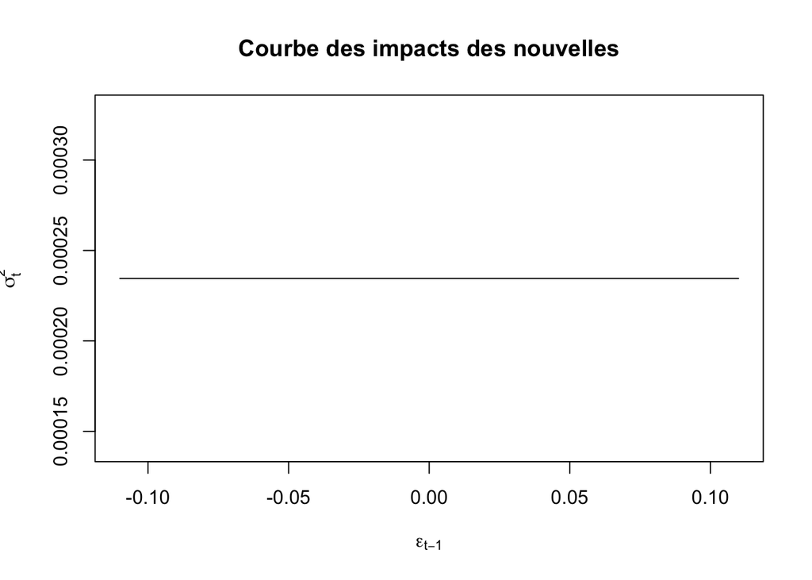

```r
nigjrgarch=newsimpact(z=NULL, fit2)
plot(nigjrgarch$zx,nigjrgarch$zy, xlab=nigjrgarch$xexpr,ylab=nigjrgarch$yexpr ,type="l", main = "Courbe des impacts des nouvelles")
```

### **Hyperbolique généralisée skew t**

```r
spec2 = ugarchspec(variance.model=list(model="gjrGARCH", garchOrder=c(1,1)),
                   mean.model=list(armaOrder=c(1,1)),distribution.model="ghst",fixed.pars=list(alpha1=0, gamma1=0, mu=0))
fit2= ugarchfit(spec = spec2,data = rt,out.sample=length(rtt),solver="hybrid")
show(fit2)
```

```
##
## *---------------------------------*
## *          GARCH Model Fit        *
## *---------------------------------*
##
## Conditional Variance Dynamics
## -----------------------------------
## GARCH Model  : gjrGARCH(1,1)
## Mean Model   : ARFIMA(1,0,1)
## Distribution : ghst
##
## Optimal Parameters
## ------------------------------------
##         Estimate  Std. Error    t value Pr(>|t|)
## mu       0.00000          NA         NA       NA
## ar1      0.77619    0.110710     7.0110  0.00000
## ma1     -0.81652    0.102171    -7.9917  0.00000
## omega    0.00000    0.000000     2.0222  0.04316
## alpha1   0.00000          NA         NA       NA
## beta1    0.99900    0.000074 13540.8478  0.00000
## gamma1   0.00000          NA         NA       NA
## skew    -0.14922    0.132713    -1.1244  0.26084
## shape    8.19957    0.981301     8.3558  0.00000
##
## Robust Standard Errors:
##         Estimate  Std. Error    t value Pr(>|t|)
## mu       0.00000          NA         NA       NA
## ar1      0.77619    0.247201    3.13992 0.001690
## ma1     -0.81652    0.237978   -3.43106 0.000601
## omega    0.00000    0.000001    0.15341 0.878071
## alpha1   0.00000          NA         NA       NA
## beta1    0.99900    0.000918 1087.89575 0.000000
## gamma1   0.00000          NA         NA       NA
## skew    -0.14922    0.415388   -0.35924 0.719419
## shape    8.19957   19.655638    0.41716 0.676561
##
## LogLikelihood : 6766.421
##
## Information Criteria
## ------------------------------------
```

[output cut: 49 more lines]

```
## Negative Sign Bias   4.744 2.207e-06 ***
## Positive Sign Bias   3.760 1.739e-04 ***
## Joint Effect        38.453 2.267e-08 ***
##
##
## Adjusted Pearson Goodness-of-Fit Test:
## ------------------------------------
##   group statistic p-value(g-1)
## 1    20     75.50    1.093e-08
## 2    30     93.96    8.845e-09
## 3    40    112.91    4.095e-09
## 4    50    127.92    5.685e-09
##
##
## Elapsed time : 1.058656
```

**Ce modèle est incorrect**

#### **Courbe des impacts des nouvelles**

On voit que la courbe est constante, ce qui signifie que l’impact des nouvelles (bonnes ou mauvaises) sur la variance conditionnelle est insensible à la valeur de $\epsilon_{t-1}$. L’impact des mauvaises nouvelles est à gauche (valeurs négatives de $\epsilon_{t-1}$ et celui des bonnes (quand elles sont positives) à droite.

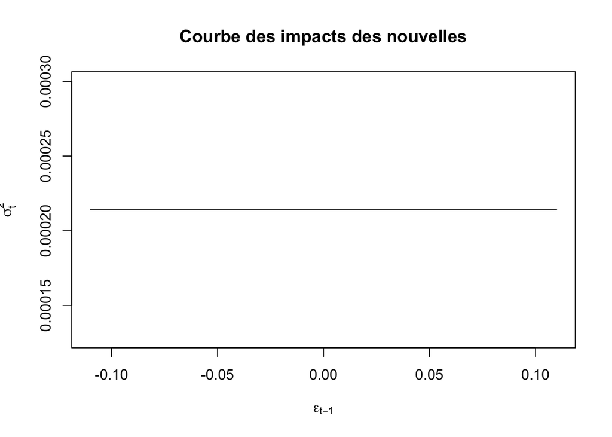

```r
nigjrgarch=newsimpact(z=NULL, fit2)
plot(nigjrgarch$zx,nigjrgarch$zy, xlab=nigjrgarch$xexpr,ylab=nigjrgarch$yexpr ,type="l", main = "Courbe des impacts des nouvelles")
```

## **EGARCH**

$$v_t = \sigma_t \varepsilon_t \\
ln(\sigma_t^2) = \alpha_0 +
\frac{1+\beta_1L+\dots+\beta_{s-1}L^{s-1}}{1-\alpha_1L-\dots-\alpha_mL^m}g(\varepsilon_{t-1})
\\
g(\varepsilon_t) = \theta\varepsilon_t+\gamma (\vert \varepsilon_t \vert
- E[\vert \varepsilon_t \vert])$$

avec : $\theta$ et $\gamma$, des constantes réelles et L, l’opérateur de retard.

### **Gaussienne inverse asymétrique**

```r
spec3 = ugarchspec(variance.model=list(model="eGARCH", garchOrder=c(1,1)),
mean.model=list(armaOrder=c(1,1)),distribution.model="nig",fixed.pars=list(mu=0))
fit3 = ugarchfit(spec = spec3, data = rt,out.sample=length(rtt),solver="hybrid")
show(fit3)
```

```
##
## *---------------------------------*
## *          GARCH Model Fit        *
## *---------------------------------*
##
## Conditional Variance Dynamics
## -----------------------------------
## GARCH Model  : eGARCH(1,1)
## Mean Model   : ARFIMA(1,0,1)
## Distribution : nig
##
## Optimal Parameters
## ------------------------------------
##         Estimate  Std. Error     t value Pr(>|t|)
## mu      0.000000          NA          NA       NA
## ar1     0.720907    0.045554  1.5825e+01 0.000000
## ma1    -0.758988    0.042562 -1.7832e+01 0.000000
## omega  -0.066682    0.001224 -5.4476e+01 0.000000
## alpha1 -0.074866    0.008959 -8.3565e+00 0.000000
## beta1   0.991681    0.000000  3.1751e+06 0.000000
## gamma1  0.070754    0.008495  8.3289e+00 0.000000
## skew   -0.126324    0.038777 -3.2577e+00 0.001123
## shape   2.138595    0.405480  5.2742e+00 0.000000
##
## Robust Standard Errors:
##         Estimate  Std. Error     t value Pr(>|t|)
## mu      0.000000          NA          NA       NA
## ar1     0.720907    0.014927  4.8296e+01 0.000000
## ma1    -0.758988    0.013705 -5.5381e+01 0.000000
## omega  -0.066682    0.001212 -5.4998e+01 0.000000
## alpha1 -0.074866    0.009893 -7.5672e+00 0.000000
## beta1   0.991681    0.000000  3.2741e+06 0.000000
## gamma1  0.070754    0.009386  7.5380e+00 0.000000
## skew   -0.126324    0.038742 -3.2607e+00 0.001112
## shape   2.138595    0.460408  4.6450e+00 0.000003
##
## LogLikelihood : 6923.035
##
## Information Criteria
## ------------------------------------
```

[output cut: 51 more lines]

```
## Negative Sign Bias 0.03348 0.9733
## Positive Sign Bias 0.13067 0.8960
## Joint Effect       0.30909 0.9583
##
##
## Adjusted Pearson Goodness-of-Fit Test:
## ------------------------------------
##   group statistic p-value(g-1)
## 1    20     19.66      0.41520
## 2    30     24.80      0.68856
## 3    40     46.82      0.18238
## 4    50     63.49      0.07982
##
##
## Elapsed time : 1.312107
```

- Tous les coefficients restants sont significatifs car leur p-value est inférieure à 5%.
- On regarde le test de Ljung-Box sur les résidus standardisés pour évaluer l’autocorrélation des aléas. Les p-values sont supérieures à 5%, donc on accepte $H_0$, donc l’autocorrélation est bien prise en compte.
- On regarde la présence d’effets ARCH (hétéroscédasticité conditionnelle) avec le test d’Engle. Les p-values pour les lag 3, 5 et 7 sont supérieures à 5% donc on accepte $H_0$: homoscédasticité conditionnelle.
- On regarde le test de stabilité dans le temps de Nyblom. La valeur de la statistique jointe est supérieure à 2.11 la valeur tabulée à 5% donc il y a au moins un coefficient qui n’est pas stable dans le temps. On peut voir que les statistiques de $\beta_1$, $\alpha_0$, skew, shape sont supérieures à 0.47 la valeur tabulée des statistiques individuelles. On rejette donc $H_0$ pour ces coefficients et ils ne sont pas stables dans le temps. Cependant, pour remédier à cela, il faudrait réaliser un modèle à changement de régime, que nous ne traiterons pas. Nous allons donc continuer avec ce modèle.
- On regarde l’effet de levier par le test d’Engle et Ng. La p-value de l’effet joint est supérieure à 5%. On accepte donc la 4ème hypothèse nulle : Il n’y a pas d’effet de levier (ni signe ni taille).
- Le test de goodness-of-fit de Pearson nous donne les 4 p-values supérieures à 5%.

Son BIC vaut **-5.3934 > -5.3947**

**Ce modèle est correct mais n’est pas meilleur que le APARCH avec une distribution nig selon le critère du BIC**

#### **Courbe des impacts des nouvelles**

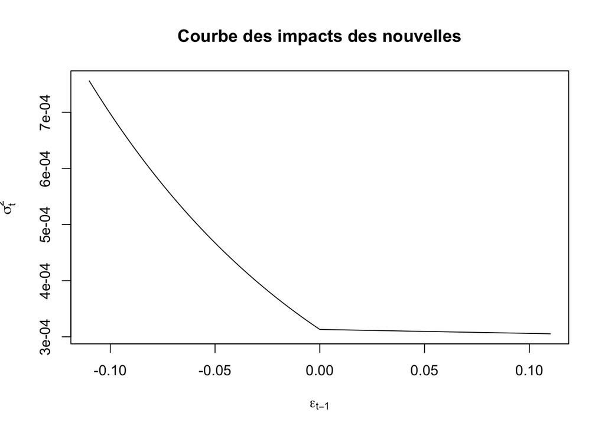

```r
niegarch=newsimpact(z=NULL, fit3)
plot(niegarch$zx,niegarch$zy, xlab=niegarch$xexpr,ylab=niegarch$yexpr ,type="l", main = "Courbe des impacts des nouvelles")
```

### **Hyperbolique généralisée skew t**

```r
spec3 = ugarchspec(variance.model=list(model="eGARCH", garchOrder=c(1,1)),
mean.model=list(armaOrder=c(1,1)),distribution.model="ghst", fixed.pars=list(mu=0))
fit3 = ugarchfit(spec = spec3, data = rt,out.sample=length(rtt),solver="hybrid")
show(fit3)
```

```
##
## *---------------------------------*
## *          GARCH Model Fit        *
## *---------------------------------*
##
## Conditional Variance Dynamics
## -----------------------------------
## GARCH Model  : eGARCH(1,1)
## Mean Model   : ARFIMA(1,0,1)
## Distribution : ghst
##
## Optimal Parameters
## ------------------------------------
##          Estimate  Std. Error  t value Pr(>|t|)
## mu       0.000000          NA       NA       NA
## ar1      0.811323    0.026336   30.807        0
## ma1     -0.862258    0.022910  -37.636        0
## omega   -0.122090    0.002571  -47.478        0
## alpha1  -0.074323    0.012073   -6.156        0
## beta1    0.981225    0.000142 6921.737        0
## gamma1   0.136802    0.010809   12.656        0
## skew   -37.928963    3.038110  -12.484        0
## shape   25.000000    0.756198   33.060        0
##
## Robust Standard Errors:
##          Estimate  Std. Error   t value Pr(>|t|)
## mu       0.000000          NA        NA       NA
## ar1      0.811323    0.021960   36.9462 0.000000
## ma1     -0.862258    0.021802  -39.5489 0.000000
## omega   -0.122090    0.004051  -30.1396 0.000000
## alpha1  -0.074323    0.027395   -2.7130 0.006668
## beta1    0.981225    0.000340 2889.4212 0.000000
## gamma1   0.136802    0.020170    6.7826 0.000000
## skew   -37.928963    6.518580   -5.8186 0.000000
## shape   25.000000    1.988488   12.5724 0.000000
##
## LogLikelihood : 6680.156
##
## Information Criteria
## ------------------------------------
```

[output cut: 51 more lines]

```
## Negative Sign Bias  0.4834 0.6289
## Positive Sign Bias  0.3387 0.7349
## Joint Effect        0.5126 0.9161
##
##
## Adjusted Pearson Goodness-of-Fit Test:
## ------------------------------------
##   group statistic p-value(g-1)
## 1    20     279.4    3.235e-48
## 2    30     306.1    4.973e-48
## 3    40     325.6    6.600e-47
## 4    50     350.3    4.048e-47
##
##
## Elapsed time : 1.258693
```

**Ce modèle est correct mais n’est pas meilleur que le APARCH avec une distribution nig selon le critère de goodness-of-fit**

#### **Courbe des impacts des nouvelles**

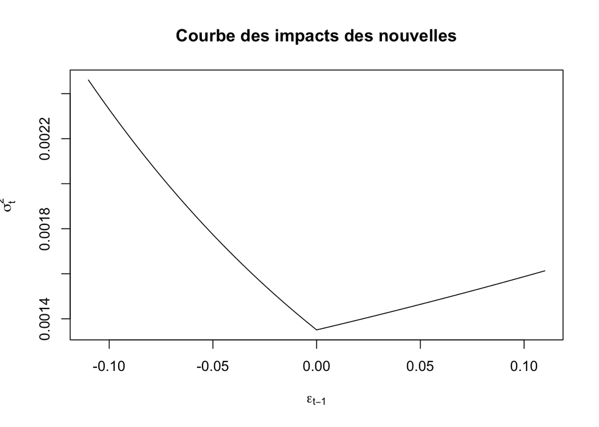

```r
niegarch=newsimpact(z=NULL, fit3)
plot(niegarch$zx,niegarch$zy, xlab=niegarch$xexpr,ylab=niegarch$yexpr ,type="l", main = "Courbe des impacts des nouvelles")
```

## **IGARCH**

Lorsque dans un modèle GARCH, on a
$$\sum_{i=1}^{max\{m,s\}}(\alpha_i+\beta_i) \ge
1$$
, alors le processus exibe une forte persistence et on obtient un modèle IGARCH.

Pour un IGARCH(1,1) :

$$v_t=\sigma_t\varepsilon_t \\
\sigma^2_t=\alpha_0+\beta_1\sigma_{t-1}^2+(1-\beta_1)v_{t-1}^2$$

avec :  
$\{\varepsilon_t\}$ iid $N(0,1)$  
$0 \lt \beta_1 \lt1$

### **Gaussienne inverse asymétrique**

On estime un modèle ARMA(1,1)-IGARCH(1,1) avec une distribution *nig*. Il n’est donc pas nécessaire de prendre en compte la saisonnalité car dans le projet 1 nous avons vu qu’il n’y en avait pas.

```r
spec4 = ugarchspec(variance.model=list(model="iGARCH", garchOrder=c(1,1)),
mean.model=list(armaOrder=c(1,1)),distribution.model="nig")
fit4 = ugarchfit(spec = spec4, data = rt,out.sample=length(rtt),solver="hybrid")
show(fit4)
```

```
##
## *---------------------------------*
## *          GARCH Model Fit        *
## *---------------------------------*
##
## Conditional Variance Dynamics
## -----------------------------------
## GARCH Model  : iGARCH(1,1)
## Mean Model   : ARFIMA(1,0,1)
## Distribution : nig
##
## Optimal Parameters
## ------------------------------------
##         Estimate  Std. Error  t value Pr(>|t|)
## mu      0.000555    0.000163   3.3992 0.000676
## ar1     0.878817    0.059865  14.6800 0.000000
## ma1    -0.913662    0.051950 -17.5874 0.000000
## omega   0.000002    0.000001   1.4062 0.159658
## alpha1  0.063019    0.009615   6.5543 0.000000
## beta1   0.936981          NA       NA       NA
## skew   -0.101895    0.040132  -2.5390 0.011118
## shape   1.784447    0.303786   5.8740 0.000000
##
## Robust Standard Errors:
##         Estimate  Std. Error   t value Pr(>|t|)
## mu      0.000555    0.000201   2.75603 0.005851
## ar1     0.878817    0.087987   9.98798 0.000000
## ma1    -0.913662    0.075253 -12.14122 0.000000
## omega   0.000002    0.000002   0.78055 0.435070
## alpha1  0.063019    0.024597   2.56206 0.010405
## beta1   0.936981          NA        NA       NA
## skew   -0.101895    0.040630  -2.50788 0.012146
## shape   1.784447    0.351991   5.06958 0.000000
##
## LogLikelihood : 6892.926
##
## Information Criteria
## ------------------------------------
##
## Akaike       -5.3902
```

[output cut: 48 more lines]

```
## Negative Sign Bias  0.5078 0.6116
## Positive Sign Bias  0.1996 0.8418
## Joint Effect        3.6939 0.2965
##
##
## Adjusted Pearson Goodness-of-Fit Test:
## ------------------------------------
##   group statistic p-value(g-1)
## 1    20     25.88       0.1337
## 2    30     33.35       0.2639
## 3    40     44.15       0.2629
## 4    50     47.84       0.5203
##
##
## Elapsed time : 0.731411
```

La p-value du coefficient $\alpha_0$ est supérieure à 0.05, cependant sa valeur est strictement positive donc il reste inchangé.

- Tous les coefficients restants sont significatifs car leur p-value est inférieure à 5%.
- On regarde le test de Ljung-Box sur les résidus standardisés pour évaluer l’autocorrélation des aléas. Les p-values sont supérieures à 5%, donc on accepte $H_0$ donc l’autocorrélation est bien prise en compte.
- On regarde la présence d’effets ARCH (hétéroscédasticité conditionnelle) avec le test d’Engle. Les p-values pour les lag 3, 5 et 7 sont supérieures à 5% donc on accepte $H_0$: homoscédasticité conditionnelle.
- On regarde le test de stabilité dans le temps de Nyblom. La valeur de la statistique jointe est supérieure à 1.9 la valeur tabulée à 5% donc il y a au moins un coefficient qui n’est pas stable dans le temps. On peut voir que les statistiques de $\alpha_0$, skew, shape sont supérieures à 0.47 la valeur tabulée des statistiques individuelles. On rejette donc $H_0$ pour ces coefficients et ils ne sont pas stables dans le temps. Cependant, pour remédier à cela, il faudrait réaliser un modèle à changement de régime, que nous ne traiterons pas. Nous allons donc continuer avec ce modèle.
- On regarde l’effet de levier par le test d’Engle et Ng. La p-value de l’effet joint est supérieure à 5%. On accepte donc la 4ème hypothèse nulle : Il n’y a pas d’effet de levier (ni signe ni taille).
- Le test de goodness-of-fit de Pearson nous donne les 4 p-values supérieures à 5%.

Son BIC vaut **-5.3733 > -5.3947**

**Ce modèle est correct mais n’est pas meilleur que le APARCH avec une distribution nig selon le critère du BIC**

### **Hyperbolique généralisée skew t**

```r
spec4 = ugarchspec(variance.model=list(model="iGARCH", garchOrder=c(1,1)),
                   mean.model=list(armaOrder=c(1,1)),distribution.model="ghst", fixed.pars=list(mu=0,alpha1=0, ar1=0))
fit4 = ugarchfit(spec = spec4, data = rt,out.sample=length(rtt),solver="hybrid")
show(fit4)
```

```
##
## *---------------------------------*
## *          GARCH Model Fit        *
## *---------------------------------*
##
## Conditional Variance Dynamics
## -----------------------------------
## GARCH Model  : iGARCH(1,1)
## Mean Model   : ARFIMA(1,0,1)
## Distribution : ghst
##
## Optimal Parameters
## ------------------------------------
##         Estimate  Std. Error    t value Pr(>|t|)
## mu        0.0000          NA         NA       NA
## ar1       0.0000          NA         NA       NA
## ma1      -0.8795    0.003619 -242.99528  0.00000
## omega     0.0000    0.000000    0.97965  0.32726
## alpha1    0.0000          NA         NA       NA
## beta1     1.0000          NA         NA       NA
## skew      4.8895    0.218966   22.33013  0.00000
## shape     8.2116    0.088985   92.28061  0.00000
##
## Robust Standard Errors:
##         Estimate  Std. Error    t value Pr(>|t|)
## mu        0.0000          NA         NA       NA
## ar1       0.0000          NA         NA       NA
## ma1      -0.8795    0.013882 -63.354399  0.00000
## omega     0.0000    0.000005   0.062509  0.95016
## alpha1    0.0000          NA         NA       NA
## beta1     1.0000          NA         NA       NA
## skew      4.8895    0.476187  10.268094  0.00000
## shape     8.2116    0.762619  10.767575  0.00000
##
## LogLikelihood : 4534.445
##
## Information Criteria
## ------------------------------------
##
## Akaike       -3.5463
```

[output cut: 45 more lines]

```
## Negative Sign Bias   29.687 1.315e-166 ***
## Positive Sign Bias   27.167 5.888e-143 ***
## Joint Effect       1629.640  0.000e+00 ***
##
##
## Adjusted Pearson Goodness-of-Fit Test:
## ------------------------------------
##   group statistic p-value(g-1)
## 1    20     678.8   1.115e-131
## 2    30     753.1   7.754e-140
## 3    40     809.1   1.266e-144
## 4    50     843.2   3.275e-145
##
##
## Elapsed time : 0.06284904
```

La p-value du coefficient $\alpha_0$ est supérieure à 0.05 et sa valeur est nulle alors que par hypothèse il doit être strictement positif.

**Ce modèle est incorrect**

## **ARCH-M**

$$r_t = \mu+c\sigma_t^2 + v_t \qquad
v_t=\sigma_t \varepsilon_t \\
\sigma_t^2 = \alpha_0+\alpha_1v_{t-1}^2+\beta_1\sigma_{t-1}^2$$

avec : $c$ (appelé paramètre de prime de risque) et $\mu$, des constantes.

### **Gaussienne inverse asymétrique**

```r
spec5 = ugarchspec(mean.model=list(armaOrder=c(1,1),archm=TRUE),distribution.model="nig",fixed.pars=list(mu=0, archm=0))
fit5 = ugarchfit(spec = spec5,data = rt,out.sample=length(rtt),solver="hybrid")
show(fit5)
```

```
##
## *---------------------------------*
## *          GARCH Model Fit        *
## *---------------------------------*
##
## Conditional Variance Dynamics
## -----------------------------------
## GARCH Model  : sGARCH(1,1)
## Mean Model   : ARFIMA(1,0,1)
## Distribution : nig
##
## Optimal Parameters
## ------------------------------------
##         Estimate  Std. Error  t value Pr(>|t|)
## mu      0.000000          NA       NA       NA
## ar1     0.820576    0.087785   9.3476 0.000000
## ma1    -0.857777    0.078742 -10.8935 0.000000
## archm   0.000000          NA       NA       NA
## omega   0.000003    0.000002   1.9746 0.048318
## alpha1  0.059535    0.010340   5.7576 0.000000
## beta1   0.932153    0.013185  70.6980 0.000000
## skew   -0.124904    0.038881  -3.2125 0.001316
## shape   1.898726    0.344876   5.5055 0.000000
##
## Robust Standard Errors:
##         Estimate  Std. Error   t value Pr(>|t|)
## mu      0.000000          NA        NA       NA
## ar1     0.820576    0.091430   8.97490 0.000000
## ma1    -0.857777    0.083142 -10.31703 0.000000
## archm   0.000000          NA        NA       NA
## omega   0.000003    0.000003   0.93425 0.350176
## alpha1  0.059535    0.029335   2.02949 0.042408
## beta1   0.932153    0.033035  28.21695 0.000000
## skew   -0.124904    0.039049  -3.19868 0.001381
## shape   1.898726    0.386644   4.91078 0.000001
##
## LogLikelihood : 6891.487
##
## Information Criteria
## ------------------------------------
```

[output cut: 50 more lines]

```
## Negative Sign Bias  0.2106 0.8332
## Positive Sign Bias  0.4610 0.6448
## Joint Effect        1.8849 0.5966
##
##
## Adjusted Pearson Goodness-of-Fit Test:
## ------------------------------------
##   group statistic p-value(g-1)
## 1    20     24.69       0.1711
## 2    30     32.83       0.2846
## 3    40     47.79       0.1579
## 4    50     58.64       0.1629
##
##
## Elapsed time : 1.161045
```

Son BIC vaut **-5.3722 > -5.3947**

**Ce modèle est correct mais n’est pas meilleur que le APARCH avec une distribution nig selon le critère du BIC**

### **Hyperbolique généralisée skew t**

```r
spec5 = ugarchspec(mean.model=list(armaOrder=c(1,1),archm=TRUE),distribution.model="ghst",fixed.pars=list(mu=0, alpha1=0, archm=0))
fit5 = ugarchfit(spec = spec5,data = rt,out.sample=length(rtt),solver="hybrid")
show(fit5)
```

```
##
## *---------------------------------*
## *          GARCH Model Fit        *
## *---------------------------------*
##
## Conditional Variance Dynamics
## -----------------------------------
## GARCH Model  : sGARCH(1,1)
## Mean Model   : ARFIMA(1,0,1)
## Distribution : ghst
##
## Optimal Parameters
## ------------------------------------
##         Estimate  Std. Error    t value Pr(>|t|)
## mu       0.00000          NA         NA       NA
## ar1      0.76823    0.115043     6.6778  0.00000
## ma1     -0.80883    0.106864    -7.5688  0.00000
## archm    0.00000          NA         NA       NA
## omega    0.00000    0.000000     2.0113  0.04429
## alpha1   0.00000          NA         NA       NA
## beta1    0.99900    0.000073 13595.9255  0.00000
## skew    -0.14900    0.132875    -1.1213  0.26214
## shape    8.19957    0.982904     8.3422  0.00000
##
## Robust Standard Errors:
##         Estimate  Std. Error    t value Pr(>|t|)
## mu       0.00000          NA         NA       NA
## ar1      0.76823    0.260170    2.95281 0.003149
## ma1     -0.80883    0.251492   -3.21612 0.001299
## archm    0.00000          NA         NA       NA
## omega    0.00000    0.000001    0.15259 0.878719
## alpha1   0.00000          NA         NA       NA
## beta1    0.99900    0.000907 1101.21102 0.000000
## skew    -0.14900    0.419123   -0.35550 0.722214
## shape    8.19957   19.612673    0.41807 0.675892
##
## LogLikelihood : 6766.419
##
## Information Criteria
## ------------------------------------
```

[output cut: 49 more lines]

```
## Negative Sign Bias  4.7640 2.005e-06 ***
## Positive Sign Bias  3.7543 1.777e-04 ***
## Joint Effect       38.5096 2.205e-08 ***
##
##
## Adjusted Pearson Goodness-of-Fit Test:
## ------------------------------------
##   group statistic p-value(g-1)
## 1    20     74.47    1.636e-08
## 2    30     94.31    7.790e-09
## 3    40    114.79    2.156e-09
## 4    50    126.43    9.143e-09
##
##
## Elapsed time : 0.7937281
```

La p-value du coefficient $\alpha_0$ est supérieure à 0.05 et sa valeur est nulle, alors que par hypothèse ça doit êre strictement positif.

De plus les coefficients sont tous significatifs sauf skew et shape.

**Ce modèle est incorrect**

## **GARCH**

Un modèle GARCH(m,s) est formulé comme cela :

$$\sigma_t^2 =
\alpha_0+\sum_{i=1}^m\alpha_iv_{t-i}^2+\sum_{j=1}^s\beta_j\sigma_{t-j}^2$$

avec :
$v_t = \sigma_t\varepsilon_t$
$\{\varepsilon_t\}$ iid $N(0,1)$ $\alpha_0 \gt 0$
$\alpha_i \ge 0$
$\beta_j \ge 0$
$$\sum_{i=1}^{max\{m,s\}}(\alpha_i+\beta_i)
\lt1$$
On va s’intéresser à un modèle GARCH(1,1) :

$$\sigma_t^2 =
\alpha_0+\alpha_1v_{t-1}^2+\beta_1\sigma_{t-1}^2$$

### **Gaussienne inverse asymétrique**

```r
spec6 = ugarchspec(distribution.model="nig",fixed.pars=list(alpha1=0, mu=0))
fit6a = ugarchfit(spec = spec6, data = rt,out.sample=length(rtt),solver="hybrid")
show(fit6a)
```

```
##
## *---------------------------------*
## *          GARCH Model Fit        *
## *---------------------------------*
##
## Conditional Variance Dynamics
## -----------------------------------
## GARCH Model  : sGARCH(1,1)
## Mean Model   : ARFIMA(1,0,1)
## Distribution : nig
##
## Optimal Parameters
## ------------------------------------
##         Estimate  Std. Error    t value Pr(>|t|)
## mu      0.000000          NA         NA       NA
## ar1     0.777586    0.104421    7.44662 0.000000
## ma1    -0.819178    0.095421   -8.58487 0.000000
## omega   0.000000    0.000002    0.15444 0.877262
## alpha1  0.000000          NA         NA       NA
## beta1   0.999000    0.000615 1623.27783 0.000000
## skew   -0.080322    0.032071   -2.50447 0.012263
## shape   1.324580    0.842875    1.57150 0.116066
##
## Robust Standard Errors:
##         Estimate  Std. Error   t value Pr(>|t|)
## mu      0.000000          NA        NA       NA
## ar1     0.777586    3.411906  0.227904  0.81972
## ma1    -0.819178    3.270722 -0.250458  0.80223
## omega   0.000000    0.000152  0.001539  0.99877
## alpha1  0.000000          NA        NA       NA
## beta1   0.999000    0.062454 15.995759  0.00000
## skew   -0.080322    0.705058 -0.113923  0.90930
## shape   1.324580   86.639593  0.015288  0.98780
##
## LogLikelihood : 6779.77
##
## Information Criteria
## ------------------------------------
##
## Akaike       -5.3024
```

[output cut: 47 more lines]

```
## Negative Sign Bias  4.8324 1.429e-06 ***
## Positive Sign Bias  3.8292 1.317e-04 ***
## Joint Effect       39.8151 1.166e-08 ***
##
##
## Adjusted Pearson Goodness-of-Fit Test:
## ------------------------------------
##   group statistic p-value(g-1)
## 1    20     49.61    1.495e-04
## 2    30     71.93    1.643e-05
## 3    40     84.92    2.956e-05
## 4    50     81.81    2.270e-03
##
##
## Elapsed time : 1.125462
```

**Ce modèle est incorrect**

#### **Courbe des impacts des nouvelles**

On voit que la courbe est constante, ce qui signifie que l’impact des nouvelles (bonnes ou mauvaises) sur la variance conditionnelle est insensible à la valeur de $\epsilon_{t-1}$. L’impact des mauvaises nouvelles est à gauche (valeurs négatives de $\epsilon_{t-1}$ et celui des bonnes (quand elles sont positives) à droite.

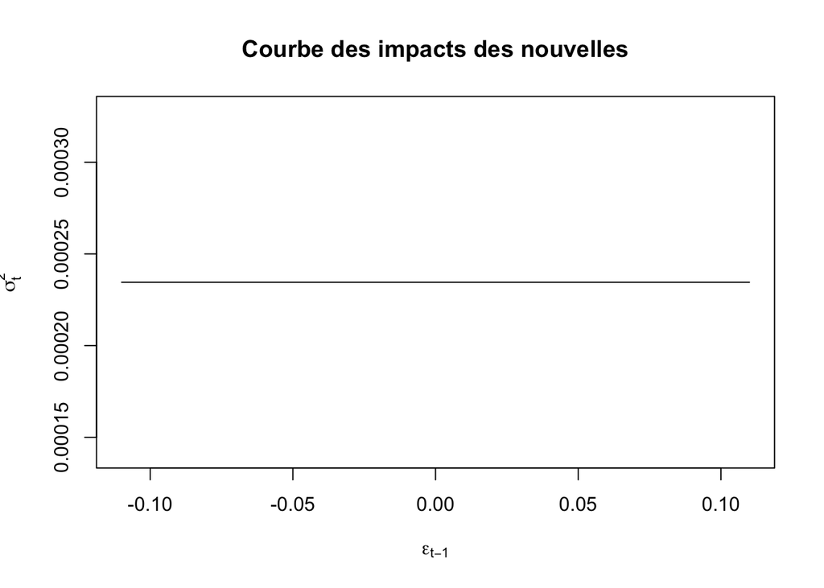

```r
nigarch=newsimpact(z=NULL, fit6a)
plot(nigarch$zx,nigarch$zy, xlab=nigarch$xexpr,ylab=nigarch$yexpr ,type="l", main = "Courbe des impacts des nouvelles")
```

#### **Prévisions conditionnelles et non conditionnelles**

**Attention:** les abscisses sont incorrectes pour les 4 graphes. En effet elles vont de 2020 à 2024 (rtt) et non de 1977 à 1980.

A gauche on a les prévisions non conditionnelles et à droite les prévisions conditionnelles avec en haut les prévisions pour le rendement et en bas celles de la volatilité.

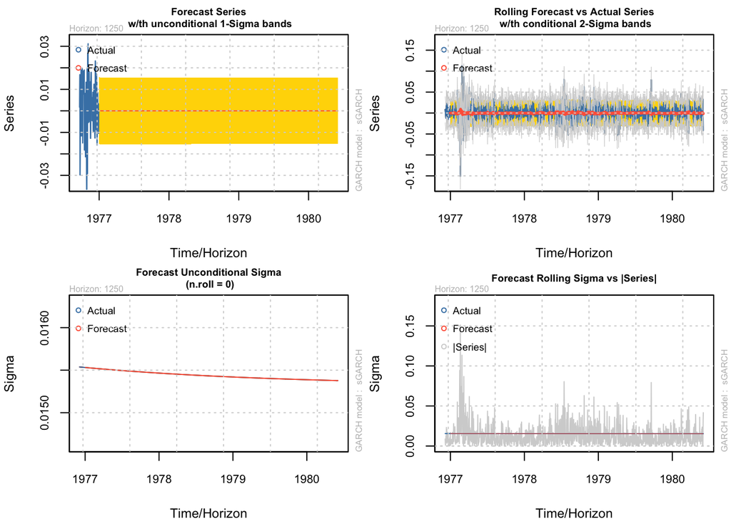

```r
# Faire des prévisions
prev <- ugarchforecast(
  fit6a,
  n.ahead = length(rtt),
  n.roll = length(rtt)
)

# Ajuster les marges pour éviter les erreurs de graphique
par(mar = c(4, 4, 2, 1)) # Réduit les marges (bas, gauche, haut, droite)

# Afficher le graphique
plot(prev, which = "all")
```

### **Hyperbolique généralisée skew t**

```r
spec6 = ugarchspec(distribution.model="ghst", fixed.pars=list(alpha1=0,mu=0))
fit6b = ugarchfit(spec = spec6, data = rt,out.sample=length(rtt),solver="hybrid")
show(fit6b)
```

```
##
## *---------------------------------*
## *          GARCH Model Fit        *
## *---------------------------------*
##
## Conditional Variance Dynamics
## -----------------------------------
## GARCH Model  : sGARCH(1,1)
## Mean Model   : ARFIMA(1,0,1)
## Distribution : ghst
##
## Optimal Parameters
## ------------------------------------
##         Estimate  Std. Error    t value Pr(>|t|)
## mu       0.00000          NA         NA       NA
## ar1      0.77619    0.110710     7.0110  0.00000
## ma1     -0.81652    0.102171    -7.9917  0.00000
## omega    0.00000    0.000000     2.0222  0.04316
## alpha1   0.00000          NA         NA       NA
## beta1    0.99900    0.000074 13540.8478  0.00000
## skew    -0.14922    0.132713    -1.1244  0.26084
## shape    8.19957    0.981301     8.3558  0.00000
##
## Robust Standard Errors:
##         Estimate  Std. Error    t value Pr(>|t|)
## mu       0.00000          NA         NA       NA
## ar1      0.77619    0.247201    3.13992 0.001690
## ma1     -0.81652    0.237978   -3.43106 0.000601
## omega    0.00000    0.000001    0.15341 0.878071
## alpha1   0.00000          NA         NA       NA
## beta1    0.99900    0.000918 1087.89575 0.000000
## skew    -0.14922    0.415388   -0.35924 0.719419
## shape    8.19957   19.655638    0.41716 0.676561
##
## LogLikelihood : 6766.421
##
## Information Criteria
## ------------------------------------
##
## Akaike       -5.2919
```

[output cut: 47 more lines]

```
## Negative Sign Bias   4.744 2.207e-06 ***
## Positive Sign Bias   3.760 1.739e-04 ***
## Joint Effect        38.453 2.267e-08 ***
##
##
## Adjusted Pearson Goodness-of-Fit Test:
## ------------------------------------
##   group statistic p-value(g-1)
## 1    20     75.50    1.093e-08
## 2    30     93.96    8.845e-09
## 3    40    112.91    4.095e-09
## 4    50    127.92    5.685e-09
##
##
## Elapsed time : 0.5520761
```

La p-value du coefficient $\alpha_0$ est supérieure à 0.05 et sa valeur est nulle, alors que par hypothèse ça doit êre strictement positif.

Toutes les pvalues sont inférieures à 5% sauf pour skew et shape.

Donc skew et shape ne sont pas significatifs.

**Ce modèle est incorrect**

#### **Courbe des impacts des nouvelles**

On voit que la courbe est constante, ce qui signifie que l’impact des nouvelles (bonnes ou mauvaises) sur la variance conditionnelle est insensible à la valeur de $\epsilon_{t-1}$. L’impact des mauvaises nouvelles est à gauche (valeurs négatives de $\epsilon_{t-1}$ et celui des bonnes (quand elles sont positives) à droite.

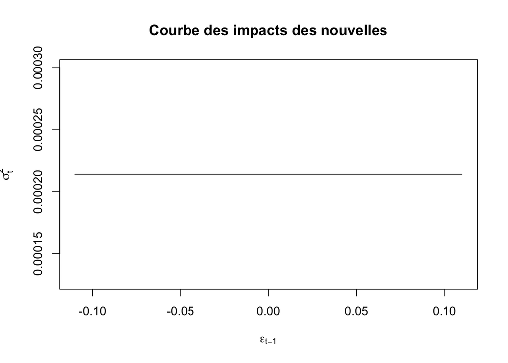

```r
nigarch=newsimpact(z=NULL, fit6b)
plot(nigarch$zx,nigarch$zy, xlab=nigarch$xexpr,ylab=nigarch$yexpr ,type="l", main = "Courbe des impacts des nouvelles")
```

#### **Prévisions conditionnelles et non conditionnelles**

**Attention**: les abscisses sont incorrectes pour les 4 graphes. En effet elles vont de 2020 à 2024 (rtt) et non de 1977 à 1980.

A gauche on a les prévisions non conditionnelles et à droite les prévisions conditionnelles avec en haut les prévisions pour le rendement et en bas celles de la volatilité.

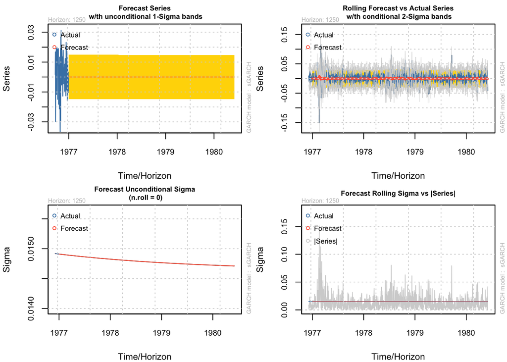

```r
# Faire des prévisions
prev <- ugarchforecast(
  fit6b,
  n.ahead = length(rtt),
  n.roll = length(rtt)
)

# Ajuster les marges pour éviter les erreurs de graphique
par(mar = c(4, 4, 2, 1)) # Réduit les marges (bas, gauche, haut, droite)

# Afficher le graphique
plot(prev, which = "all")
```

# **Modèle retenu**

## **Tableau récapitulatif avec le test de Pearson**

| Modèle estimé | Gaussienne inversée asymétrique (nig) | Hyperbolique généralisée skew t (ghst) |
| --- | --- | --- |
| APARCH(1,1) | Modèle correct: 4 p-values > 5% | Modèle correct: 2 p-values > 5% |
| GJR GARCH(1,1) | Modèle incorrect | Modèle incorrect |
| EGARCH(1,1) | Modèle correct: 4 p-values > 5% | Modèle correct: 3 p-values > 5% |
| IGARCH(1,1) | Modèle correct: 4 p-values > 5% | Modèle incorrect |
| ARCH-M(1,1) | Modèle correct: 4 p-values > 5% | Modèle incorrect |
| GARCH(1,1) | Modèle incorrect | Modèle incorrect |

La meilleure distribution est la **nig** au vu des résultats des tests que l’on a obtenus.

Selon le tableau ci-dessus, **Les modèles ayant le plus grand nombre de p-values > 5% dans le test de Pearson sont APARCH, EGARCH, IGARCH et ARCH-M pour la Gaussienne inverse asymétrique (nig)**

Le modèle retenu est celui qui correspond à notre série et qui minimise le critère d’information de bayésien **BIC**, défini de la façon suivante :

$SBIC = log (\hat\sigma_T^2(k)) + \frac{log(T)}{T}k$

avec $k$, nombre de paramètres.

- Le BIC du modèle APARCH avec un distribution nig est de -5.3947
- Le BIC du modèle EGARCH avec un distribution nig est de -5.3934
- Le BIC du modèle IGARCH avec un distribution nig est de -5.3733
- Le BIC du modèle ARCH-M avec un distribution nig est de -5.3722

**Le meilleur modèle pour notre série est un ARMA(0,5)-APARCH(1,1) avec un distribution nig et delta=1, ma3=0, mu=0, ma1=0** car il correspond au BIC le plus petit.

Ce modèle est en adéquation avec les résultats du projet puisqu’il permet de modéliser l’asymétrie, les queues de distribution épaisses de nos données, il prend bien en compte l’autocorrélation des aléas, les clusters de volatilité ainsi que l’effet de levier.

```r
specbest = ugarchspec(variance.model=list(model="apARCH", garchOrder=c(1,1)),
mean.model=list(armaOrder=c(0,5)),distribution.model="nig",fixed.pars=list(delta=1, ma3=0, mu=0,  ma1=0))
fitbest = ugarchfit(spec = spec1,data = rt,out.sample=length(rtt),solver="hybrid")
```

# **Value at Risk**

**La Value-at-Risk est définie comme la perte maximale potentielle qui ne devrait être atteinte qu’avec une probabilité donnée sur un horizon temporel donné (Manganelli et Engle, 2001).**

**Nous nous intéresserons à la Value at Risk à 95%**

## **Les tests et les hypothèses des Values-at-Risk**

On définit la violation (le dépassement ou exception) comme une situation dans laquelle on observe ex-post une perte plus importante en valeur absolue que la VaR prévue ex-ante. Formellement, il y a violation si et seulement si:

$$r_t \le VaR_{t+1 \vert t}(q)$$

Dans la pratique, on définit souvent une variable dichotomique associée à l’occurrence d’une violation appelée elle aussi violation ou fonction Hit (Campbell, 2006 ; Engle et Manganelli, 2004) :

$$I_t(q)=\left\{{1 \text{ si } r_t \le
VaR_{t+1 \vert t}(q) \atop 0 \text{ sinon}}\right.$$

| Test | Statistique | Hypothèse | Distribution sous $H_0$ | Règle de décision |
| --- | --- | --- | --- | --- |
| LR (Likelihood Ratio) de Kupiec | $$LR = -2\log\left(\frac{q^N(1-q)^{T-N}}{\hat f^N(1-\hat f)^{T-N}}\right)$$ avec : $\hat f$, le taux de violation empirique $N$: le nombre de violations de la VaR $T$: le nombre initial d’observations… | $H_0$ : $f=q$ : le taux (ou le nombre) de violation observé est égal au taux (ou nombre) de violation théorique $H_a$ : $f \neq q$ : le taux (ou le nombre) de violation observé est différent du taux (… | $LR \sim \chi^2(1)$ | On accepte si la p-value est supérieure à 5% |
| LR (Likelihood Ratio) de Christoffersen | $$LR_{Christ}$$ | $H_0$ : $f=q$ : le taux (ou le nombre) de violation observé est égal au taux (ou nombre) de violation théorique et les violations sont indépendantes $H_a$ : $f \neq q$ : le taux (ou le nombre) de viol… | $LR_{Christ}\sim \chi^2(2)$ | On accepte si la p-value est supérieure à 5% |

Le test de Christoffersen pose la condition supplémentaire que les violations sont indépendantes entre elles. De ce fait ce test est plus efficace et utile que le test de Kupiec. Ainsi c’est à partir ce test que nous allons faire nos conclusions sur nos Values-at-Risk.

## **VaR Paramétrique**

Formellement, la prévision $VaR_{t+1|t}(q)$ s’écrit :

$$VaR_{t+1|t}(q) =
-F_{r_{t+1}}^{-1}(q|\Omega_t)$$

où $F_{r_{t+1}}^{-1}(q|\Omega_t)$ désigne la fonction quantile associée à la fonction de distribution des rendements en t+1, conditionnelle à l’ensemble d’information disponible en t.

On considère l’exemple d’un modèle GARCH(1,1) sous l’hypothèse de la distribution de Student. On suppose ainsi que les rendements d’un actif $r_t$ satisfont le modèle suivant :

$$\left\{
\begin{array}{l}
r_t = \mu_t + v_t \\
v_t = \sigma_t \epsilon_t \\
\sigma_t^2 = \alpha_0 + \alpha_1 v_{t-1}^2 + \beta_1
\sigma_{t-1}^2 \\
\epsilon_t \sim iid~student(\nu)
\end{array}
\right.$$

```
  avec les contraintes suivantes sur les paramètres suivants : $\alpha_0 \geq 0, \alpha_1 \geq 0, \beta_1 \geq 0, \nu \geq 2.$
      Soient $\hat\alpha_0, \hat\alpha_1, \hat\beta_1, \hat\nu, \hat\mu$ des estimateurs convergents (MV) des paramètres et soit $\sigma_1^2$ une condition initiale sur le processus de variance conditionnelle $\sigma_t^2$.

    À partir de ces différents éléments, il est possible de prévoir la variance conditionnelle des rendements pour la date T + 1 de la façon suivante :

      <center> $$ \hat \sigma_{T+1}^2=\hat \alpha_0+\hat\alpha_1v_T^2+\hat\beta_1\sigma_T^2 $$ </center>

      On note $VaR_{T+1|T}(q)$ la prévision de la VaR de niveau q anticipée pour la date T+1 conditionnellement à l'information disponible en T. Par définition de la VaR, on a :
```

$$Pr\left( r_{T+1} \leq VaR_{T+1|T}(q) \mid \Omega_T \right) = 1 - q
\Leftrightarrow
Pr\left( \epsilon_{T+1} \leq \frac{VaR_{T+1|T}(q) \mid \Omega_T -
\mu}{\sigma_{T+1}} \right) = 1 - q$$

Sachant que l’on suppose que la distribution conditionnelle des rendements est une distribution de Student à $\nu$ degrés de liberté, de variance égale à $\frac{\nu}{(\nu-2)\nu}$, on peut en déduire une prévision du fractile de la distribution conditionnelle valable pour la date T + 1, c’est-à-dire la VaR. Soit $G(x, \nu)$, la fonction de répartition de la loi de Student à $\nu$ degrés de liberté. La prévision de le VaR est définie par la quantité suivante :

$$VaR_{T+1|t}(q)=\hat \mu-G^{-1}(q,\hat
\nu)\hat\sigma_{T+1}$$

avec $\hat \nu$ la valeur estimée du paramètre $\nu$.

```r
no_cores <- detectCores() - 1
cl <- makeCluster(no_cores)

roll = ugarchroll(specbest, data=rt,n.ahead=1, forecast.length=length(rtt),
  refit.every=1, refit.window="moving", solver = "hybrid",
  cluster=cl,fit.control = list(), calculate.VaR=TRUE,
  VaR.alpha=0.05,keep.coef = TRUE)

stopCluster(cl)
```

### **Estimation de la VaR paramétrique**

```r
VaR95 <- as.numeric(quantile(fitbest, probs = 0.05))

# Calcul de la moyenne
mean_VaR <- mean(VaR95)
mean_VaR
```

```
## [1] -0.02824303
```

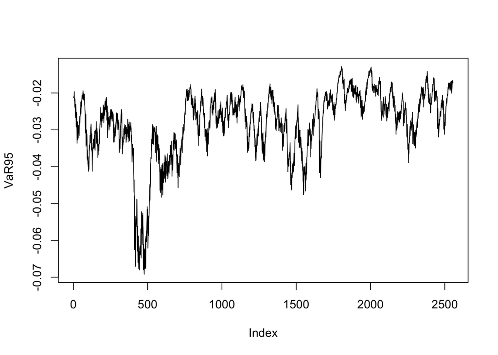

```r
plot(VaR95, type='l',col=1)
```

### **Estimation par fenêtre glissante**

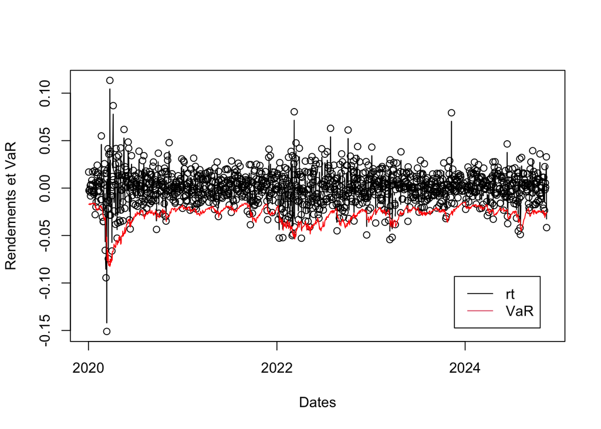

```r
valueatrisk<-zoo(roll@forecast$VaR[,1])
reelles<-zoo(roll@forecast$VaR[,2])#=rtt
index<-rownames(roll@forecast$VaR)
plot(dates[2556:N],reelles,type='b',xlab="Dates",ylab="Rendements et VaR")
lines(dates[2556:N],valueatrisk,type='l',col="red")
legend("bottomright",inset=.05,c("rt","VaR"),col=1:2,lty=c(1,1))
```

### **Estimation de tous les paramètres du modèle APARCH**

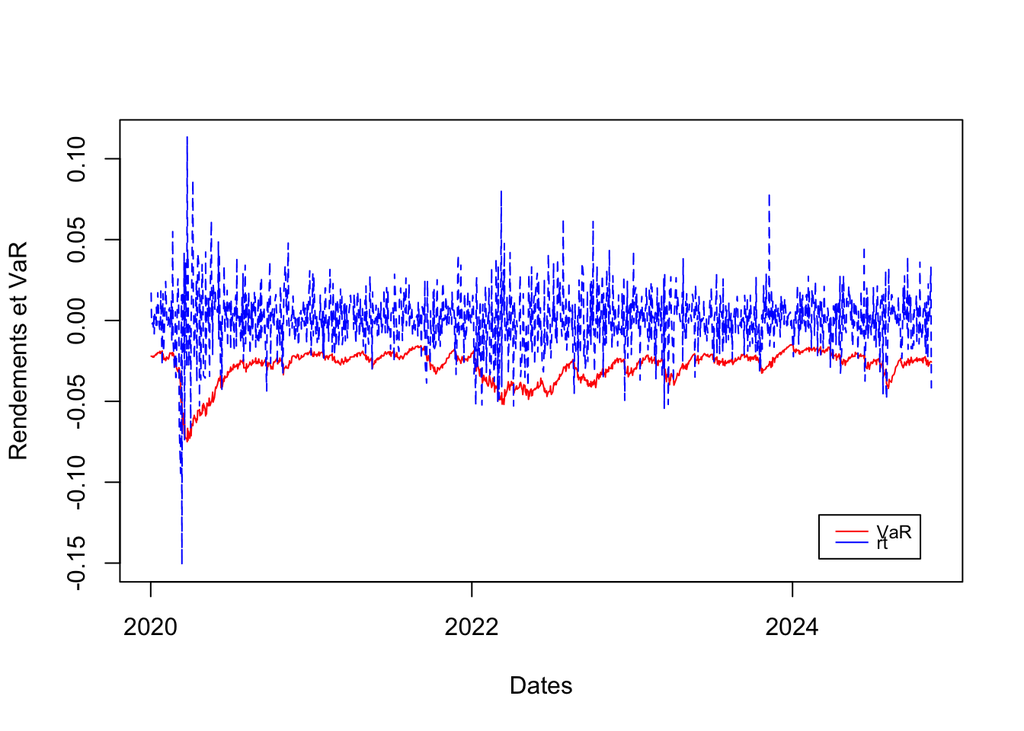

```r
fit = ugarchfit(specbest, data = rte)
spec2 = specbest
setfixed(spec2)<-as.list(coef(fit))
filt = ugarchfilter(spec=spec2, data=rtt)
VaR=fitted(filt)+sigma(filt)*qdist("nig",p=0.05,mu=0,sigma=1, skew = coef(filt)["skew"],shape=coef(filt)["shape"])
matplot(dates[2556:N],cbind(VaR,rtt),type="l",col=c("red","blue"),xlab="Dates",ylab="Rendements et VaR")
legend("bottomright",inset=.05,c("VaR","rt"),col=c("red","blue"),lty=c(1,1),x.intersp=0.5,y.intersp=0.5,cex=0.75)
```

```r
report(roll,type="VaR",VaR.alpha=0.05,conf.level=0.95)
```

```
## VaR Backtest Report
## ===========================================
## Model:               apARCH-nig
## Backtest Length: 1250
## Data:
##
## ==========================================
## alpha:               5%
## Expected Exceed: 62.5
## Actual VaR Exceed:   61
## Actual %:            4.9%
##
## Unconditional Coverage (Kupiec)
## Null-Hypothesis: Correct Exceedances
## LR.uc Statistic: 0.038
## LR.uc Critical:      3.841
## LR.uc p-value:       0.845
## Reject Null:     NO
##
## Conditional Coverage (Christoffersen)
## Null-Hypothesis: Correct Exceedances and
##                  Independence of Failures
## LR.cc Statistic: 2.84
## LR.cc Critical:      5.991
## LR.cc p-value:       0.242
## Reject Null:     NO
```

On en conclut que la VaR Paramétrique a bien été estimée.

Voici ci-dessous le tableau pour les VaR.

```r
alpha=0.95 #VaR à 95%

backTestVaR <- function(x, p = alpha) {
  normal.VaR = as.numeric(VaR(x, p=p, method="gaussian"))
  historical.VaR = as.numeric(VaR(x, p=p, method="historical"))
  modified.VaR = as.numeric(VaR(x, p=p, method="modified"))
  ans = c(normal.VaR, historical.VaR, modified.VaR)
  names(ans) = c("Normal", "HS", "Modified")
  return(ans)
}

# rolling 1-step ahead estimates of VaR
VaR.results = rollapply(as.zoo(rt), width=T,
                        FUN = backTestVaR, p=alpha, by.column = FALSE,
                        align = "right")

violations.mat = matrix(0, 3, 5)
rownames(violations.mat) = c("Normal", "HS", "Modified")
colnames(violations.mat) = c("En1", "n1", "1-alpha", "Percent", "VR")
violations.mat[, "En1"] = (1-alpha)*Q
violations.mat[, "1-alpha"] = 1 - alpha

# Show Normal VaR violations
normalVaR.violations = as.numeric(as.zoo(rt[index(VaR.results)])) < VaR.results[, "Normal"]
violation.dates = index(normalVaR.violations[which(normalVaR.violations)])


for(i in colnames(VaR.results)) {
  VaR.violations = as.numeric(as.zoo(rt[index(VaR.results)])) < VaR.results[, i]
  violations.mat[i, "n1"] = sum(VaR.violations)
  violations.mat[i, "Percent"] = sum(VaR.violations)/T
  violations.mat[i, "VR"] = violations.mat[i, "n1"]/violations.mat[i, "En1"]
}


resultats<-data.frame(matrix(NA,ncol=4,nrow=3))
colnames(resultats)<-c("expected.exceed","actual.exceed","Kupiecpv","Christoffersenpv")
rownames(resultats)<-c("Normale","HS","CF")

# normale
VaR.test1 = VaRTest(1-alpha,actual=coredata(rt[index(VaR.results)]), VaR=coredata(VaR.results[,"Normal"]))
resultats[1,1]=VaR.test1$expected.exceed
resultats[1,2]=VaR.test1$actual.exceed
resultats[1,3]=VaR.test1$uc.LRp
resultats[1,4]=VaR.test1$cc.LRp

# historique
VaR.test2 = VaRTest(1-alpha,actual=coredata(rt[index(VaR.results)]), VaR=coredata(VaR.results[,"HS"]))
resultats[2,1]=VaR.test2$expected.exceed
resultats[2,2]=VaR.test2$actual.exceed
resultats[2,3]=VaR.test2$uc.LRp
resultats[2,4]=VaR.test2$cc.LRp



# modifie
VaR.test3 = VaRTest(1-alpha, actual=coredata(rt[index(VaR.results)]), VaR=coredata(VaR.results[,"Modified"]))

resultats[3,1]=VaR.test3$expected.exceed
resultats[3,2]=VaR.test3$actual.exceed
resultats[3,3]=VaR.test3$uc.LRp
resultats[3,4]=VaR.test3$cc.LRp

resultats
```

```
##         expected.exceed actual.exceed  Kupiecpv Christoffersenpv
## Normale              62            66 0.6572287       0.07030575
## HS                   62            65 0.7520836       0.06263415
## CF                   62            67 0.5680130       0.07719156
```

## **VaR Normale**

Lorsque $\Delta p_t \sim N(E[\Delta p_t],\sigma(\Delta p_t)$ :

$$Pr[\frac{\Delta p_t-E[\Delta
p_t]}{\sigma(\Delta p_t)} \le \frac{VaR_q-E[\Delta p_t]}{\sigma(\Delta
p_t)}] = 1-q$$

avec $E[\Delta p_t]$, l’espérance des variations des prix, $\sigma(\Delta p_t)$, a volatilité (c’est-à-dire l’écart-type) de la variation des prix et $\frac{VaR_q-E[\Delta p_t]}{\sigma(\Delta p_t)}$, le quantile de la distribution normale centrée réduite $\Phi^{-1}(1-q)$.

Comme $\Phi^{-1}(1-q) = -\Phi^{-1}(q)$ et comme l’espérance de la variation des valeurs de cours est nulle :

$VaR_q = -\Phi^{-1}(q)\sigma(\Delta p_t)$

```r
VaR(rte, p=0.95, method="gaussian")
```

```
##            [,1]
## VaR -0.02909962
```

Selon le tableau des VaR on a:

- On obtient un nombre de violations de 66 pour une valeur attendue de 62.
- La p-value du test de Kupiec est 0.6572287 > 5% donc on accepte l’hypothèse nulle : $f= q$.
- La p-value du test de Christoffersen est 0.07030575 > 5% donc on accepte l’hypothèse nulle : $f = q$ et les violations sont indépendantes les unes des autres.

On en conclut que la VaR Normale a bien été estimée.

## **VaR Cornish-Fisher**

On modifie l’équation de la VaR normale pour tenir compte de l’asymétrie et des queues de distribution épaisses :

$MVaR_q = E[\Delta p_t] + z_{cf}(q) \sigma(\Delta p_t)$

avec :

$$z_{cf} =
z_c+\frac{(z_c^2-1)s}{6}+\frac{(z_c^3-3z_c)k}{24}+\frac{2z_c^3-5z_cs^2}{36}$$

où $z_c = -\Phi^{-1}(q)$, s est le skewness et k est l’excès de kurtosis.

```r
VaR(rte, p=0.95, method="modified")
```

```
##            [,1]
## VaR -0.02842925
```

Selon le tableau des VaR on a:

- On obtient un nombre de violations de 67 pour une valeur attendue de 62.
- La p-value du test de Kupiec est 0.5680130 > 5% donc on accepte l’hypothèse nulle : $f = q$.
- La p-value du test de Christoffersen est 0.07719156 > 5% donc on accepte l’hypothèse nulle : $f = q$ et les violations sont indépendantes les unes des autres.

On en conclut que la VaR de Cornish-Fisher a bien été estimée.

## **VaR Historique**

La VaR historique est une estimation non paramétrique de la VaR qui consiste à utiliser la distribution observée des historiques pour estimer la distribution des facteurs de risque.

La valeur dont on désire déterminer la VaR est le facteur de risque lui-même comme pour le cours d’une action. On note $X(0)$ la valeur observée aujourd’hui du risque et $X(1)$ la valeur future. On suppose que la distribution de la variable aléatoire $\Delta = \frac{X(1)-X(0)}{X(0)}$ est représentée par les observations
$$\Delta(t)=\frac{X(t)-X(t-1)}{X(t-1)},
~t=-T+1,...,-1,0$$

La relation $X(1)-X(0)=\Delta * X(0)$ permet d’obtenir la valeur future du risque X par $X^{(t)}(1)=X(0)+\Delta(t)*X(0), ~t=-T+1,...,-1,0$ et donc la distribution de la variation future de valeur par : $\Delta p^{(t)}=X^{(t)}(1)-X(0)=\Delta(t)*X(0), ~t=-T+1,...,-1,0$.

Ensuite, on range les variations de valeur futures par ordre croissant et la VaR est égale au quantile de la distribution des variations futures.

```r
VaR(rte, p=0.95, method="historical")
```

```
##           [,1]
## VaR -0.0296133
```

La perte potentielle maximale atteinte avec 95% de chance est de 2.961336%, selon la méthode historique. C’est-à-dire que la perte potentielle ne dépassera cette valeur que 5% du temps.

Selon le tableau des VaR on a:

- On obtient un nombre de violations de 65 pour une valeur attendue de 62.
- La p-value du test de Kupiec est 0.7520836 > 5% donc on accepte l’hypothèse nulle : $f = q$.
- La p-value du test de Christoffersen est 0.06263415 > 5% donc on accepte l’hypothèse nulle : $f =q$ et les violations sont indépendantes les unes des autres.

On en conclut que la VaR Historique a bien été estimée.

# **Backtesting**

Cela consiste à comparer, au quotidien, la VaR estimée avec les pertes réalisées. En principe, si nous testons une VaR à 99%, on doit s’attendre à ce que les rendements quotidiens du portefeuille d´epassent la VaR une fois sur 100. Les autorités de Bâle exigent un backtest sur 250 jours d’historique, au minimum ce qui donnerait un nombre de dépassements autorisés de 2.5. Si le nombre de dépassement est significativement plus élevé , la VaR et donc les risques sont sous-évalués. Si par contre, le nombre d’exceptions est significativement plus faible alors la VaR est sur-estimée et la banque est trop conservatrice.

**Remarque :** le comité de Bâle exige une VaR sur 10 ou 20 jours. Or avec une VaR à 10 jours et une confiance à 99% on doit s’attendre à une exception tous les 100*10 = 1000 jours, soit environ 4 ans. Il n’est donc pas possible de backtester la VaR à 10 jours et on se ramènera à une VaR quotidienne.

Pour savoir si les VaR sont bien estimées ou non, on utilise les tests de Kupiec et Christoffersen. Il est important de noter qu’on tirera nos conclusions à partir des résultats du test Christoffersen. Si on a une pvalue supérieure à 5%, la VaR est bien estimée, sinon on a 2 cas:

- le nombre de violations estimées est supérieur au nombre de violations théoriques: **VaR sous-estimée**.
- le nombre de violations estimées est inférieur au nombre de violations théoriques: **VaR sur-estimée**.

[output not shown]

**Selon le test de Christoffersen, toutes les VaR sont bien estimées (Règle de décision de la pvalue: VaR bien estimée si la pvalue est supérieure 5%).**

# **Annexe: Modèle ARMA-GARCH**

## **APARCH**

### **Gaussienne inverse asymétrique**

On estime un modèle ARMA(1,1)-APARCH(1,1) avec une distribution *nig*. Il n’est donc pas nécessaire de prendre en compte la saisonnalité car dans le projet 1 nous avons vu qu’il n’y en avait pas. Rappelons que dans R, $\alpha_0$ est nommé $\omega$.

```r
spec1 = ugarchspec(variance.model=list(model="apARCH", garchOrder=c(1,1)),
mean.model=list(armaOrder=c(1,1)),distribution.model="nig")
fit1= ugarchfit(spec = spec1,data = rt,out.sample=length(rtt),solver="hybrid")
show(fit1)
```

```
##
## *---------------------------------*
## *          GARCH Model Fit        *
## *---------------------------------*
##
## Conditional Variance Dynamics
## -----------------------------------
## GARCH Model  : apARCH(1,1)
## Mean Model   : ARFIMA(1,0,1)
## Distribution : nig
##
## Optimal Parameters
## ------------------------------------
##         Estimate  Std. Error   t value Pr(>|t|)
## mu      0.000152    0.000253   0.60246 0.546869
## ar1     0.730875    0.034522  21.17107 0.000000
## ma1    -0.768493    0.032360 -23.74831 0.000000
## omega   0.000193    0.000218   0.88446 0.376448
## alpha1  0.044746    0.010663   4.19631 0.000027
## beta1   0.956836    0.002260 423.44296 0.000000
## gamma1  0.942704    0.343245   2.74645 0.006024
## delta   0.982377    0.321325   3.05727 0.002234
## skew   -0.119985    0.040939  -2.93083 0.003381
## shape   2.203095    0.424829   5.18584 0.000000
##
## Robust Standard Errors:
##         Estimate  Std. Error   t value Pr(>|t|)
## mu      0.000152    0.000296   0.51587 0.605947
## ar1     0.730875    0.009623  75.95053 0.000000
## ma1    -0.768493    0.014556 -52.79734 0.000000
## omega   0.000193    0.000675   0.28507 0.775594
## alpha1  0.044746    0.026961   1.65968 0.096979
## beta1   0.956836    0.006371 150.17744 0.000000
## gamma1  0.942704    0.763439   1.23481 0.216901
## delta   0.982377    0.825316   1.19030 0.233927
## skew   -0.119985    0.040930  -2.93146 0.003374
## shape   2.203095    0.492521   4.47309 0.000008
##
## LogLikelihood : 6925.533
##
```

[output cut: 55 more lines]

```
## Negative Sign Bias  0.2576 0.7967
## Positive Sign Bias  0.1125 0.9105
## Joint Effect        0.3781 0.9447
##
##
## Adjusted Pearson Goodness-of-Fit Test:
## ------------------------------------
##   group statistic p-value(g-1)
## 1    20     21.48      0.31103
## 2    30     32.81      0.28554
## 3    40     53.74      0.05837
## 4    50     51.99      0.35837
##
##
## Elapsed time : 4.853003
```

On regarde, dans un premier temps, la valeur de $\delta$. Elle est proche de 1, donc on va donc la fixer à 1.

```r
spec1 = ugarchspec(variance.model=list(model="apARCH", garchOrder=c(1,1)),
mean.model=list(armaOrder=c(1,1)),distribution.model="nig",fixed.pars=list(delta=1))
fit1= ugarchfit(spec = spec1,data = rt,out.sample=length(rtt),solver="hybrid")
show(fit1)
```

```
##
## *---------------------------------*
## *          GARCH Model Fit        *
## *---------------------------------*
##
## Conditional Variance Dynamics
## -----------------------------------
## GARCH Model  : apARCH(1,1)
## Mean Model   : ARFIMA(1,0,1)
## Distribution : nig
##
## Optimal Parameters
## ------------------------------------
##         Estimate  Std. Error   t value Pr(>|t|)
## mu      0.000156    0.000257   0.60607 0.544468
## ar1     0.731149    0.036414  20.07893 0.000000
## ma1    -0.768871    0.034330 -22.39645 0.000000
## omega   0.000178    0.000041   4.30272 0.000017
## alpha1  0.044422    0.003968  11.19445 0.000000
## beta1   0.956759    0.002455 389.64913 0.000000
## gamma1  0.946698    0.157475   6.01174 0.000000
## delta   1.000000          NA        NA       NA
## skew   -0.119913    0.040901  -2.93175 0.003371
## shape   2.201627    0.420911   5.23063 0.000000
##
## Robust Standard Errors:
##         Estimate  Std. Error    t value Pr(>|t|)
## mu      0.000156    0.000253    0.61575 0.538060
## ar1     0.731149    0.010746   68.03870 0.000000
## ma1    -0.768871    0.010717  -71.74204 0.000000
## omega   0.000178    0.000041    4.38018 0.000012
## alpha1  0.044422    0.003179   13.97490 0.000000
## beta1   0.956759    0.000801 1195.15979 0.000000
## gamma1  0.946698    0.147584    6.41463 0.000000
## delta   1.000000          NA         NA       NA
## skew   -0.119913    0.040788   -2.93989 0.003283
## shape   2.201627    0.475421    4.63089 0.000004
##
## LogLikelihood : 6925.527
##
```

[output cut: 54 more lines]

```
## Negative Sign Bias  0.2697 0.7874
## Positive Sign Bias  0.1197 0.9047
## Joint Effect        0.3737 0.9456
##
##
## Adjusted Pearson Goodness-of-Fit Test:
## ------------------------------------
##   group statistic p-value(g-1)
## 1    20     20.87       0.3442
## 2    30     32.64       0.2923
## 3    40     55.71       0.0403
## 4    50     51.95       0.3598
##
##
## Elapsed time : 2.679069
```

La p-value du coefficient $\mu$ du modèle ARMA est la pvalue la plus élevée (sans considérer $\alpha_0$, skew et shape) et elle est supérieure à 5%. On rejette $H_0$ du test de significativité des coefficients et fixe la valeur de $\mu$ à 0.

```r
spec1 = ugarchspec(variance.model=list(model="apARCH", garchOrder=c(1,1)),
                   mean.model=list(armaOrder=c(1,1)),distribution.model="nig",fixed.pars=list(delta=1,mu=0))
fit1= ugarchfit(spec = spec1,data = rt,out.sample=length(rtt),solver="hybrid")
show(fit1)
```

```
##
## *---------------------------------*
## *          GARCH Model Fit        *
## *---------------------------------*
##
## Conditional Variance Dynamics
## -----------------------------------
## GARCH Model  : apARCH(1,1)
## Mean Model   : ARFIMA(1,0,1)
## Distribution : nig
##
## Optimal Parameters
## ------------------------------------
##         Estimate  Std. Error  t value Pr(>|t|)
## mu      0.000000          NA       NA       NA
## ar1     0.721131    0.044288  16.2827 0.000000
## ma1    -0.757861    0.041650 -18.1957 0.000000
## omega   0.000184    0.000040   4.6299 0.000004
## alpha1  0.044234    0.003918  11.2904 0.000000
## beta1   0.957077    0.002390 400.5050 0.000000
## gamma1  0.968417    0.156320   6.1951 0.000000
## delta   1.000000          NA       NA       NA
## skew   -0.127271    0.038873  -3.2740 0.001060
## shape   2.197955    0.420491   5.2271 0.000000
##
## Robust Standard Errors:
##         Estimate  Std. Error   t value Pr(>|t|)
## mu      0.000000          NA        NA       NA
## ar1     0.721131    0.013694   52.6604 0.000000
## ma1    -0.757861    0.013036  -58.1353 0.000000
## omega   0.000184    0.000039    4.6832 0.000003
## alpha1  0.044234    0.003151   14.0365 0.000000
## beta1   0.957077    0.000764 1252.6034 0.000000
## gamma1  0.968417    0.146685    6.6020 0.000000
## delta   1.000000          NA        NA       NA
## skew   -0.127271    0.038758   -3.2838 0.001024
## shape   2.197955    0.475781    4.6197 0.000004
##
## LogLikelihood : 6925.355
##
```

[output cut: 53 more lines]

```
## Negative Sign Bias 0.130186 0.8964
## Positive Sign Bias 0.007009 0.9944
## Joint Effect       0.568642 0.9036
##
##
## Adjusted Pearson Goodness-of-Fit Test:
## ------------------------------------
##   group statistic p-value(g-1)
## 1    20     22.17      0.27606
## 2    30     26.28      0.61050
## 3    40     46.60      0.18825
## 4    50     64.28      0.07043
##
##
## Elapsed time : 2.188869
```

Tous les coefficients restants sont significatifs car leur p-value est inférieure à 5%.

On regarde le test de Ljung-Box sur les résidus standardisés pour évaluer l’autocorrélation des aléas. Les p-values sont inférieures 5% donc on rejette 𝐻0 et l’autocorrélation n’est pas bien prise en compte.

On passe donc à un modèle ARMA(0,5)-APARCH(1,1) avec un distribution nig.

```r
spec1 = ugarchspec(variance.model=list(model="apARCH", garchOrder=c(1,1)),
                   mean.model=list(armaOrder=c(0,5)),distribution.model="nig")
fit1= ugarchfit(spec = spec1,data = rt,out.sample=length(rtt),solver="hybrid")
show(fit1)
```

```
##
## *---------------------------------*
## *          GARCH Model Fit        *
## *---------------------------------*
##
## Conditional Variance Dynamics
## -----------------------------------
## GARCH Model  : apARCH(1,1)
## Mean Model   : ARFIMA(0,0,5)
## Distribution : nig
##
## Optimal Parameters
## ------------------------------------
##         Estimate  Std. Error   t value Pr(>|t|)
## mu      0.000187    0.000128   1.46160 0.143851
## ma1    -0.023496    0.010628  -2.21078 0.027051
## ma2    -0.036615    0.018998  -1.92732 0.053940
## ma3    -0.009570    0.043462  -0.22019 0.825724
## ma4    -0.040424    0.013177  -3.06769 0.002157
## ma5    -0.047253    0.018191  -2.59755 0.009389
## omega   0.000178    0.000638   0.27931 0.780003
## alpha1  0.044817    0.027070   1.65559 0.097805
## beta1   0.956378    0.006931 137.99396 0.000000
## gamma1  0.912118    0.574598   1.58740 0.112422
## delta   1.000140    0.820682   1.21867 0.222969
## skew   -0.122604    0.040875  -2.99952 0.002704
## shape   2.238357    0.400176   5.59344 0.000000
##
## Robust Standard Errors:
##         Estimate  Std. Error   t value Pr(>|t|)
## mu      0.000187    0.000970  0.192569 0.847297
## ma1    -0.023496    0.082064 -0.286313 0.774639
## ma2    -0.036615    0.040467 -0.904817 0.365562
## ma3    -0.009570    0.237519 -0.040291 0.967861
## ma4    -0.040424    0.071652 -0.564163 0.572643
## ma5    -0.047253    0.038822 -1.217184 0.223534
## omega   0.000178    0.003270  0.054458 0.956571
## alpha1  0.044817    0.140630  0.318688 0.749963
## beta1   0.956378    0.033837 28.264241 0.000000
## gamma1  0.912118    2.942676  0.309962 0.756590
```

[output cut: 64 more lines]

```
## Negative Sign Bias 0.27063 0.7867
## Positive Sign Bias 0.06215 0.9504
## Joint Effect       0.30158 0.9597
##
##
## Adjusted Pearson Goodness-of-Fit Test:
## ------------------------------------
##   group statistic p-value(g-1)
## 1    20     28.04      0.08272
## 2    30     37.76      0.12769
## 3    40     52.86      0.06838
## 4    50     56.02      0.22836
##
##
## Elapsed time : 7.043145
```

On fixe désormais delta à 1 car sa valeur est proche de 1.

```r
spec1 = ugarchspec(variance.model=list(model="apARCH", garchOrder=c(1,1)),
                   mean.model=list(armaOrder=c(0,5)),distribution.model="nig",fixed.pars=list(delta=1))
fit1= ugarchfit(spec = spec1,data = rt,out.sample=length(rtt),solver="hybrid")
show(fit1)
```

```
##
## *---------------------------------*
## *          GARCH Model Fit        *
## *---------------------------------*
##
## Conditional Variance Dynamics
## -----------------------------------
## GARCH Model  : apARCH(1,1)
## Mean Model   : ARFIMA(0,0,5)
## Distribution : nig
##
## Optimal Parameters
## ------------------------------------
##         Estimate  Std. Error   t value Pr(>|t|)
## mu      0.000186    0.000219   0.84649 0.397280
## ma1    -0.023064    0.019424  -1.18735 0.235088
## ma2    -0.036761    0.019216  -1.91309 0.055737
## ma3    -0.009833    0.019059  -0.51594 0.605893
## ma4    -0.040444    0.018740  -2.15809 0.030921
## ma5    -0.047474    0.019245  -2.46678 0.013633
## omega   0.000178    0.000041   4.32940 0.000015
## alpha1  0.044760    0.004031  11.10534 0.000000
## beta1   0.956439    0.002532 377.72167 0.000000
## gamma1  0.913824    0.152382   5.99693 0.000000
## delta   1.000000          NA        NA       NA
## skew   -0.122480    0.040675  -3.01119 0.002602
## shape   2.240713    0.434721   5.15437 0.000000
##
## Robust Standard Errors:
##         Estimate  Std. Error   t value Pr(>|t|)
## mu      0.000186    0.000201    0.9224 0.356319
## ma1    -0.023064    0.020064   -1.1495 0.250342
## ma2    -0.036761    0.019663   -1.8696 0.061543
## ma3    -0.009833    0.019038   -0.5165 0.605503
## ma4    -0.040444    0.018550   -2.1803 0.029237
## ma5    -0.047474    0.019493   -2.4355 0.014872
## omega   0.000178    0.000040    4.3997 0.000011
## alpha1  0.044760    0.003223   13.8883 0.000000
## beta1   0.956439    0.000852 1122.9958 0.000000
## gamma1  0.913824    0.142564    6.4099 0.000000
```

[output cut: 63 more lines]

```
## Negative Sign Bias 0.29978 0.7644
## Positive Sign Bias 0.09227 0.9265
## Joint Effect       0.28945 0.9620
##
##
## Adjusted Pearson Goodness-of-Fit Test:
## ------------------------------------
##   group statistic p-value(g-1)
## 1    20     28.44      0.07524
## 2    30     39.17      0.09841
## 3    40     52.67      0.07071
## 4    50     55.82      0.23387
##
##
## Elapsed time : 3.263801
```

On fixe désormais ma3 à 0 car la pvalue la plus élevée (sans considérer $\alpha_0$, skew et shape)

```r
spec1 = ugarchspec(variance.model=list(model="apARCH", garchOrder=c(1,1)),
                   mean.model=list(armaOrder=c(0,5)),distribution.model="nig",fixed.pars=list(delta=1, ma3=0))
fit1= ugarchfit(spec = spec1,data = rt,out.sample=length(rtt),solver="hybrid")
show(fit1)
```

```
##
## *---------------------------------*
## *          GARCH Model Fit        *
## *---------------------------------*
##
## Conditional Variance Dynamics
## -----------------------------------
## GARCH Model  : apARCH(1,1)
## Mean Model   : ARFIMA(0,0,5)
## Distribution : nig
##
## Optimal Parameters
## ------------------------------------
##         Estimate  Std. Error  t value Pr(>|t|)
## mu      0.000172    0.000125   1.3689 0.171041
## ma1    -0.023559    0.018813  -1.2523 0.210472
## ma2    -0.036310    0.017620  -2.0608 0.039324
## ma3     0.000000          NA       NA       NA
## ma4    -0.040601    0.016420  -2.4726 0.013412
## ma5    -0.047093    0.027498  -1.7126 0.086784
## omega   0.000180    0.000041   4.4110 0.000010
## alpha1  0.045069    0.004078  11.0512 0.000000
## beta1   0.956156    0.002599 367.8321 0.000000
## gamma1  0.920443    0.152238   6.0461 0.000000
## delta   1.000000          NA       NA       NA
## skew   -0.122398    0.039639  -3.0878 0.002016
## shape   2.241456    0.435412   5.1479 0.000000
##
## Robust Standard Errors:
##         Estimate  Std. Error   t value Pr(>|t|)
## mu      0.000172    0.000064    2.6824 0.007310
## ma1    -0.023559    0.019214   -1.2261 0.220146
## ma2    -0.036310    0.017942   -2.0238 0.042995
## ma3     0.000000          NA        NA       NA
## ma4    -0.040601    0.015033   -2.7008 0.006917
## ma5    -0.047093    0.040592   -1.1602 0.245985
## omega   0.000180    0.000040    4.5013 0.000007
## alpha1  0.045069    0.003236   13.9257 0.000000
## beta1   0.956156    0.000892 1071.4186 0.000000
## gamma1  0.920443    0.145271    6.3361 0.000000
```

[output cut: 62 more lines]

```
## Negative Sign Bias 0.220060 0.8258
## Positive Sign Bias 0.004994 0.9960
## Joint Effect       0.350968 0.9502
##
##
## Adjusted Pearson Goodness-of-Fit Test:
## ------------------------------------
##   group statistic p-value(g-1)
## 1    20     27.99      0.08362
## 2    30     40.89      0.07045
## 3    40     55.74      0.04006
## 4    50     54.49      0.27358
##
##
## Elapsed time : 3.41972
```

```r
spec1 = ugarchspec(variance.model=list(model="apARCH", garchOrder=c(1,1)),
                   mean.model=list(armaOrder=c(0,5)),distribution.model="nig",fixed.pars=list(delta=1, ma3=0, mu=0))
fit1= ugarchfit(spec = spec1,data = rt,out.sample=length(rtt),solver="hybrid")
show(fit1)
```

```
##
## *---------------------------------*
## *          GARCH Model Fit        *
## *---------------------------------*
##
## Conditional Variance Dynamics
## -----------------------------------
## GARCH Model  : apARCH(1,1)
## Mean Model   : ARFIMA(0,0,5)
## Distribution : nig
##
## Optimal Parameters
## ------------------------------------
##         Estimate  Std. Error  t value Pr(>|t|)
## mu      0.000000          NA       NA       NA
## ma1    -0.022692    0.018723  -1.2120 0.225515
## ma2    -0.035927    0.019572  -1.8357 0.066408
## ma3     0.000000          NA       NA       NA
## ma4    -0.038344    0.020335  -1.8857 0.059341
## ma5    -0.045889    0.019056  -2.4081 0.016036
## omega   0.000185    0.000040   4.6026 0.000004
## alpha1  0.044763    0.003997  11.1996 0.000000
## beta1   0.956636    0.002486 384.8808 0.000000
## gamma1  0.940349    0.152163   6.1799 0.000000
## delta   1.000000          NA       NA       NA
## skew   -0.130736    0.038977  -3.3542 0.000796
## shape   2.238211    0.435273   5.1421 0.000000
##
## Robust Standard Errors:
##         Estimate  Std. Error   t value Pr(>|t|)
## mu      0.000000          NA        NA       NA
## ma1    -0.022692    0.018603   -1.2198 0.222544
## ma2    -0.035927    0.020319   -1.7681 0.077043
## ma3     0.000000          NA        NA       NA
## ma4    -0.038344    0.021522   -1.7817 0.074806
## ma5    -0.045889    0.018980   -2.4177 0.015620
## omega   0.000185    0.000040    4.6515 0.000003
## alpha1  0.044763    0.003202   13.9792 0.000000
## beta1   0.956636    0.000826 1158.3300 0.000000
## gamma1  0.940349    0.142415    6.6029 0.000000
```

[output cut: 61 more lines]

```
## Negative Sign Bias 0.27872 0.7805
## Positive Sign Bias 0.07153 0.9430
## Joint Effect       0.31447 0.9573
##
##
## Adjusted Pearson Goodness-of-Fit Test:
## ------------------------------------
##   group statistic p-value(g-1)
## 1    20     33.97      0.01852
## 2    30     40.25      0.07989
## 3    40     59.68      0.01809
## 4    50     74.14      0.01171
##
##
## Elapsed time : 2.80725
```

On fixe désormais ma1 à 0 car la pvalue est la plus élevée (sans considérer $\alpha_0$, skew et shape)

### **Hyperbolique généralisée skew t**

On estime un modèle ARMA(1,1)-APARCH(1,1) avec une distribution *ghst*. Il n’est donc pas nécessaire de prendre en compte la saisonnalité car dans le projet 1 nous avons vu qu’il n’y en avait pas.

```r
spec1 = ugarchspec(variance.model=list(model="apARCH", garchOrder=c(1,1)),
mean.model=list(armaOrder=c(1,1)),distribution.model="ghst")
fit1= ugarchfit(spec = spec1,data = rt,out.sample=length(rtt),solver="hybrid")
show(fit1)
```

```
##
## *---------------------------------*
## *          GARCH Model Fit        *
## *---------------------------------*
##
## Conditional Variance Dynamics
## -----------------------------------
## GARCH Model  : apARCH(1,1)
## Mean Model   : ARFIMA(1,0,1)
## Distribution : ghst
##
## Optimal Parameters
## ------------------------------------
##         Estimate  Std. Error    t value Pr(>|t|)
## mu      0.000356    0.000224   1.591843 0.111420
## ar1     0.733273    0.135059   5.429295 0.000000
## ma1    -0.767413    0.126214  -6.080248 0.000000
## omega   0.000189    0.000093   2.017092 0.043686
## alpha1  0.045186    0.007014   6.442265 0.000000
## beta1   0.956370    0.002803 341.186766 0.000000
## gamma1  0.927644    0.216948   4.275880 0.000019
## delta   0.974336    0.205637   4.738132 0.000002
## skew   -0.000030    0.047035  -0.000645 0.999485
## shape   8.200224    1.399977   5.857398 0.000000
##
## Robust Standard Errors:
##         Estimate  Std. Error    t value Pr(>|t|)
## mu      0.000356    0.000235   1.511752 0.130597
## ar1     0.733273    0.128667   5.698998 0.000000
## ma1    -0.767413    0.117345  -6.539802 0.000000
## omega   0.000189    0.000464   0.406047 0.684708
## alpha1  0.045186    0.016873   2.678068 0.007405
## beta1   0.956370    0.006781 141.028809 0.000000
## gamma1  0.927644    0.396748   2.338119 0.019381
## delta   0.974336    0.515785   1.889035 0.058887
## skew   -0.000030    0.019283  -0.001573 0.998745
## shape   8.200224    1.808676   4.533828 0.000006
##
## LogLikelihood : 6921.191
##
```

[output cut: 55 more lines]

```
## Negative Sign Bias  0.3061 0.7596
## Positive Sign Bias  0.1365 0.8914
## Joint Effect        0.3728 0.9458
##
##
## Adjusted Pearson Goodness-of-Fit Test:
## ------------------------------------
##   group statistic p-value(g-1)
## 1    20     32.12     0.030270
## 2    30     37.76     0.127693
## 3    40     70.39     0.001522
## 4    50     66.82     0.046038
##
##
## Elapsed time : 5.33765
```

On regarde, dans un premier temps, la valeur de $\delta$. Elle est proche de 1, on va donc la fixer à 1.

```r
spec1 = ugarchspec(variance.model=list(model="apARCH", garchOrder=c(1,1)),
mean.model=list(armaOrder=c(1,1)),distribution.model="ghst", fixed.pars=list(delta=1))
fit1= ugarchfit(spec = spec1,data = rt,out.sample=length(rtt),solver="hybrid")
show(fit1)
```

```
##
## *---------------------------------*
## *          GARCH Model Fit        *
## *---------------------------------*
##
## Conditional Variance Dynamics
## -----------------------------------
## GARCH Model  : apARCH(1,1)
## Mean Model   : ARFIMA(1,0,1)
## Distribution : ghst
##
## Optimal Parameters
## ------------------------------------
##         Estimate  Std. Error   t value Pr(>|t|)
## mu      0.000151    0.000263   0.57323 0.566491
## ar1     0.731676    0.030409  24.06150 0.000000
## ma1    -0.767168    0.028895 -26.55051 0.000000
## omega   0.000167    0.000040   4.16569 0.000031
## alpha1  0.043869    0.003798  11.55090 0.000000
## beta1   0.957983    0.002233 429.07799 0.000000
## gamma1  0.976268    0.157137   6.21285 0.000000
## delta   1.000000          NA        NA       NA
## skew   -0.412556    0.180647  -2.28376 0.022385
## shape   7.527193    1.097269   6.85994 0.000000
##
## Robust Standard Errors:
##         Estimate  Std. Error    t value Pr(>|t|)
## mu      0.000151    0.000262    0.57554 0.564924
## ar1     0.731676    0.008332   87.81291 0.000000
## ma1    -0.767168    0.008882  -86.37381 0.000000
## omega   0.000167    0.000040    4.19056 0.000028
## alpha1  0.043869    0.003106   14.12596 0.000000
## beta1   0.957983    0.000710 1349.64713 0.000000
## gamma1  0.976268    0.149181    6.54417 0.000000
## delta   1.000000          NA         NA       NA
## skew   -0.412556    0.178570   -2.31034 0.020870
## shape   7.527193    1.155755    6.51279 0.000000
##
## LogLikelihood : 6925.018
##
```

[output cut: 54 more lines]

```
## Negative Sign Bias 0.26827 0.7885
## Positive Sign Bias 0.07801 0.9378
## Joint Effect       0.44054 0.9317
##
##
## Adjusted Pearson Goodness-of-Fit Test:
## ------------------------------------
##   group statistic p-value(g-1)
## 1    20     25.67      0.13956
## 2    30     34.22      0.23140
## 3    40     54.93      0.04679
## 4    50     54.30      0.27974
##
##
## Elapsed time : 4.310315
```

La p-value du coefficient $\mu$ du modèle ARMA est la pvalue la plus élevée (sans considérer $\alpha_0$, skew et shape) et elle est supérieure à 5%. On rejette $H_0$ du test de significativité des coefficients et fixe la valeur de $\mu$ à 0.

```r
spec1 = ugarchspec(variance.model=list(model="apARCH", garchOrder=c(1,1)),
mean.model=list(armaOrder=c(1,1)),distribution.model="ghst", fixed.pars=list(delta=1, mu=0))
fit1= ugarchfit(spec = spec1,data = rt,out.sample=length(rtt),solver="hybrid")
show(fit1)
```

```
##
## *---------------------------------*
## *          GARCH Model Fit        *
## *---------------------------------*
##
## Conditional Variance Dynamics
## -----------------------------------
## GARCH Model  : apARCH(1,1)
## Mean Model   : ARFIMA(1,0,1)
## Distribution : ghst
##
## Optimal Parameters
## ------------------------------------
##         Estimate  Std. Error  t value Pr(>|t|)
## mu      0.000000          NA       NA       NA
## ar1     0.725173    0.132077   5.4905 0.000000
## ma1    -0.759105    0.124824  -6.0814 0.000000
## omega   0.000176    0.000038   4.6928 0.000003
## alpha1  0.043410    0.003725  11.6521 0.000000
## beta1   0.957733    0.002272 421.6214 0.000000
## gamma1  0.981253    0.156141   6.2844 0.000000
## delta   1.000000          NA       NA       NA
## skew   -0.555473    0.260062  -2.1359 0.032685
## shape   9.260860    1.959086   4.7271 0.000002
##
## Robust Standard Errors:
##         Estimate  Std. Error   t value Pr(>|t|)
## mu      0.000000          NA        NA       NA
## ar1     0.725173    0.101719    7.1291 0.000000
## ma1    -0.759105    0.096588   -7.8592 0.000000
## omega   0.000176    0.000038    4.6242 0.000004
## alpha1  0.043410    0.003130   13.8709 0.000000
## beta1   0.957733    0.000750 1276.5674 0.000000
## gamma1  0.981253    0.152603    6.4301 0.000000
## delta   1.000000          NA        NA       NA
## skew   -0.555473    0.296108   -1.8759 0.060667
## shape   9.260860    2.895808    3.1980 0.001384
##
## LogLikelihood : 6923.927
##
```

[output cut: 53 more lines]

```
## Negative Sign Bias 0.15612 0.8759
## Positive Sign Bias 0.01725 0.9862
## Joint Effect       0.53881 0.9103
##
##
## Adjusted Pearson Goodness-of-Fit Test:
## ------------------------------------
##   group statistic p-value(g-1)
## 1    20     27.91      0.08514
## 2    30     28.75      0.47837
## 3    40     48.26      0.14704
## 4    50     60.13      0.13245
##
##
## Elapsed time : 2.187579
```

Tous les coefficients restants sont significatifs car leur p-value est inférieure à 5%.

On regarde le test de Ljung-Box sur les résidus standardisés pour évaluer l’autocorrélation des aléas. Les p-values sont inférieures 5% donc on rejette 𝐻0 et l’autocorrélation n’est pas bien prise en compte.

```r
spec1 = ugarchspec(variance.model=list(model="apARCH", garchOrder=c(1,1)),
mean.model=list(armaOrder=c(0,5)),distribution.model="ghst")
fit1= ugarchfit(spec = spec1,data = rt,out.sample=length(rtt),solver="hybrid")
show(fit1)
```

```
##
## *---------------------------------*
## *          GARCH Model Fit        *
## *---------------------------------*
##
## Conditional Variance Dynamics
## -----------------------------------
## GARCH Model  : apARCH(1,1)
## Mean Model   : ARFIMA(0,0,5)
## Distribution : ghst
##
## Optimal Parameters
## ------------------------------------
##          Estimate  Std. Error     t value Pr(>|t|)
## mu      -0.000352    0.000256    -1.37566 0.168926
## ma1     -0.017792    0.020200    -0.88077 0.378445
## ma2     -0.040081    0.019450    -2.06076 0.039326
## ma3     -0.029213    0.019157    -1.52494 0.127274
## ma4     -0.081578    0.020036    -4.07159 0.000047
## ma5     -0.082391    0.020503    -4.01844 0.000059
## omega    0.000000    0.000000     0.01097 0.991247
## alpha1   0.001191    0.000130     9.19088 0.000000
## beta1    0.977009    0.000857  1139.44845 0.000000
## gamma1  -1.000000    0.000983 -1017.29770 0.000000
## delta    3.500000    0.030417   115.06575 0.000000
## skew   -13.822807    1.371846   -10.07606 0.000000
## shape   24.999993    1.006611    24.83580 0.000000
##
## Robust Standard Errors:
##          Estimate  Std. Error  t value Pr(>|t|)
## mu      -0.000352         NaN      NaN      NaN
## ma1     -0.017792         NaN      NaN      NaN
## ma2     -0.040081         NaN      NaN      NaN
## ma3     -0.029213         NaN      NaN      NaN
## ma4     -0.081578         NaN      NaN      NaN
## ma5     -0.082391         NaN      NaN      NaN
## omega    0.000000         NaN      NaN      NaN
## alpha1   0.001191         NaN      NaN      NaN
## beta1    0.977009         NaN      NaN      NaN
## gamma1  -1.000000         NaN      NaN      NaN
```

[output cut: 64 more lines]

```
## Negative Sign Bias  3.8062 1.444e-04 ***
## Positive Sign Bias  1.8430 6.544e-02   *
## Joint Effect       21.3345 8.971e-05 ***
##
##
## Adjusted Pearson Goodness-of-Fit Test:
## ------------------------------------
##   group statistic p-value(g-1)
## 1    20     116.8    4.407e-16
## 2    30     141.9    8.079e-17
## 3    40     148.8    9.935e-15
## 4    50     168.7    4.604e-15
##
##
## Elapsed time : 3.036573
```

```r
spec1 = ugarchspec(variance.model=list(model="apARCH", garchOrder=c(1,1)),
                   mean.model=list(armaOrder=c(0,5)),distribution.model="ghst", fixed.pars=list(delta=1))
fit1= ugarchfit(spec = spec1,data = rt,out.sample=length(rtt),solver="hybrid")
show(fit1)
```

```
##
## *---------------------------------*
## *          GARCH Model Fit        *
## *---------------------------------*
##
## Conditional Variance Dynamics
## -----------------------------------
## GARCH Model  : apARCH(1,1)
## Mean Model   : ARFIMA(0,0,5)
## Distribution : ghst
##
## Optimal Parameters
## ------------------------------------
##         Estimate  Std. Error   t value Pr(>|t|)
## mu      0.000209    0.000282   0.73903 0.459888
## ma1    -0.020368    0.021523  -0.94634 0.343976
## ma2    -0.034306    0.022036  -1.55683 0.119510
## ma3    -0.008664    0.018925  -0.45780 0.647099
## ma4    -0.038673    0.028631  -1.35071 0.176787
## ma5    -0.047965    0.024230  -1.97961 0.047747
## omega   0.000170    0.000040   4.26272 0.000020
## alpha1  0.044075    0.003844  11.46548 0.000000
## beta1   0.956952    0.002422 395.08502 0.000000
## gamma1  0.919785    0.158722   5.79496 0.000000
## delta   1.000000          NA        NA       NA
## skew   -0.548699    0.272303  -2.01503 0.043902
## shape   9.404223    2.017554   4.66120 0.000003
##
## Robust Standard Errors:
##         Estimate  Std. Error    t value Pr(>|t|)
## mu      0.000209    0.000356    0.58631 0.557665
## ma1    -0.020368    0.024989   -0.81507 0.415034
## ma2    -0.034306    0.025670   -1.33640 0.181420
## ma3    -0.008664    0.018390   -0.47113 0.637549
## ma4    -0.038673    0.045691   -0.84639 0.397335
## ma5    -0.047965    0.034776   -1.37927 0.167812
## omega   0.000170    0.000042    4.08018 0.000045
## alpha1  0.044075    0.003202   13.76461 0.000000
## beta1   0.956952    0.000846 1130.50647 0.000000
## gamma1  0.919785    0.178691    5.14734 0.000000
```

[output cut: 63 more lines]

```
## Negative Sign Bias  0.3756 0.7073
## Positive Sign Bias  0.1656 0.8685
## Joint Effect        0.2887 0.9621
##
##
## Adjusted Pearson Goodness-of-Fit Test:
## ------------------------------------
##   group statistic p-value(g-1)
## 1    20     34.44      0.01630
## 2    30     45.86      0.02420
## 3    40     55.93      0.03863
## 4    50     55.63      0.23946
##
##
## Elapsed time : 3.318902
```

On fixe désormais ma3 à 0 car la pvalue est la plus élevée (sans considérer $\alpha_0$, skew et shape).

```r
spec1 = ugarchspec(variance.model=list(model="apARCH", garchOrder=c(1,1)),
                   mean.model=list(armaOrder=c(0,5)),distribution.model="ghst", fixed.pars=list(delta=1, ma3=0))
fit1= ugarchfit(spec = spec1,data = rt,out.sample=length(rtt),solver="hybrid")
show(fit1)
```

```
##
## *---------------------------------*
## *          GARCH Model Fit        *
## *---------------------------------*
##
## Conditional Variance Dynamics
## -----------------------------------
## GARCH Model  : apARCH(1,1)
## Mean Model   : ARFIMA(0,0,5)
## Distribution : ghst
##
## Optimal Parameters
## ------------------------------------
##         Estimate  Std. Error   t value Pr(>|t|)
## mu      0.000194    0.000288   0.67311 0.500879
## ma1    -0.020302    0.020983  -0.96752 0.333286
## ma2    -0.034428    0.023353  -1.47425 0.140415
## ma3     0.000000          NA        NA       NA
## ma4    -0.039323    0.022288  -1.76429 0.077683
## ma5    -0.048019    0.073362  -0.65455 0.512760
## omega   0.000171    0.000040   4.26796 0.000020
## alpha1  0.044319    0.003884  11.41176 0.000000
## beta1   0.956840    0.002445 391.40343 0.000000
## gamma1  0.929005    0.172112   5.39767 0.000000
## delta   1.000000          NA        NA       NA
## skew   -0.528076    0.269610  -1.95867 0.050152
## shape   9.111091    1.851354   4.92131 0.000001
##
## Robust Standard Errors:
##         Estimate  Std. Error    t value Pr(>|t|)
## mu      0.000194    0.000488    0.39651 0.691730
## ma1    -0.020302    0.028758   -0.70595 0.480222
## ma2    -0.034428    0.060172   -0.57216 0.567212
## ma3     0.000000          NA         NA       NA
## ma4    -0.039323    0.053071   -0.74095 0.458726
## ma5    -0.048019    0.292020   -0.16444 0.869387
## omega   0.000171    0.000041    4.12961 0.000036
## alpha1  0.044319    0.003382   13.10505 0.000000
## beta1   0.956840    0.000861 1111.61354 0.000000
## gamma1  0.929005    0.377689    2.45971 0.013905
```

[output cut: 62 more lines]

```
## Negative Sign Bias 0.29484 0.7681
## Positive Sign Bias 0.07361 0.9413
## Joint Effect       0.31005 0.9581
##
##
## Adjusted Pearson Goodness-of-Fit Test:
## ------------------------------------
##   group statistic p-value(g-1)
## 1    20     36.29     0.009729
## 2    30     50.87     0.007272
## 3    40     62.60     0.009632
## 4    50     62.67     0.090760
##
##
## Elapsed time : 2.700298
```

## **GJR-GARCH**

### **Gaussienne inverse asymétrique**

On estime un modèle ARMA(1,1)-GJR GARCH(1,1) avec une distribution *nig*. Il n’est donc pas nécessaire de prendre en compte la saisonnalité car dans le projet 1 nous avons vu qu’il n’y en avait pas.

```r
spec2 = ugarchspec(variance.model=list(model="gjrGARCH", garchOrder=c(1,1)),
mean.model=list(armaOrder=c(1,1)),distribution.model="nig")
fit2= ugarchfit(spec = spec2,data = rt,out.sample=length(rtt),solver="hybrid")
show(fit2)
```

```
##
## *---------------------------------*
## *          GARCH Model Fit        *
## *---------------------------------*
##
## Conditional Variance Dynamics
## -----------------------------------
## GARCH Model  : gjrGARCH(1,1)
## Mean Model   : ARFIMA(1,0,1)
## Distribution : nig
##
## Optimal Parameters
## ------------------------------------
##         Estimate  Std. Error  t value Pr(>|t|)
## mu      0.000322    0.000250  1.28615 0.198390
## ar1     0.776675    0.092153  8.42811 0.000000
## ma1    -0.818422    0.083961 -9.74768 0.000000
## omega   0.000003    0.000002  1.68426 0.092132
## alpha1  0.005852    0.006011  0.97345 0.330327
## beta1   0.937984    0.013861 67.67029 0.000000
## gamma1  0.094241    0.007315 12.88348 0.000000
## skew   -0.112528    0.040481 -2.77981 0.005439
## shape   2.055799    0.382952  5.36829 0.000000
##
## Robust Standard Errors:
##         Estimate  Std. Error   t value Pr(>|t|)
## mu      0.000322    0.000263   1.22076 0.222175
## ar1     0.776675    0.079687   9.74657 0.000000
## ma1    -0.818422    0.070647 -11.58468 0.000000
## omega   0.000003    0.000005   0.60187 0.547259
## alpha1  0.005852    0.019629   0.29811 0.765623
## beta1   0.937984    0.046054  20.36716 0.000000
## gamma1  0.094241    0.045812   2.05714 0.039672
## skew   -0.112528    0.039097  -2.87821 0.003999
## shape   2.055799    0.456547   4.50293 0.000007
##
## LogLikelihood : 6914.428
##
## Information Criteria
## ------------------------------------
```

[output cut: 52 more lines]

```
## Negative Sign Bias  0.7437 0.4571
## Positive Sign Bias  0.2634 0.7923
## Joint Effect        0.6505 0.8848
##
##
## Adjusted Pearson Goodness-of-Fit Test:
## ------------------------------------
##   group statistic p-value(g-1)
## 1    20     32.01      0.03114
## 2    30     42.95      0.04599
## 3    40     52.61      0.07150
## 4    50     56.88      0.20515
##
##
## Elapsed time : 1.39325
```

La p-value du coefficient $\alpha_0$ est supérieure à 5%, cependant sa valeur (0.000003) est strictement positive donc il reste inchangé.

La p-value du coefficient $\alpha_1$ est la pvalue la plus élevée (sans considérer $\alpha_0$, skew et shape) et elle est supérieure à 5%. On rejette $H_0$ du test de significativité des coefficients et fixe la valeur de $\alpha_1$ à 0.

```r
spec2 = ugarchspec(variance.model=list(model="gjrGARCH", garchOrder=c(1,1)),
mean.model=list(armaOrder=c(1,1)),distribution.model="nig",fixed.pars=list(alpha1=0))
fit2= ugarchfit(spec = spec2,data = rt,out.sample=length(rtt),solver="hybrid")
show(fit2)
```

```
##
## *---------------------------------*
## *          GARCH Model Fit        *
## *---------------------------------*
##
## Conditional Variance Dynamics
## -----------------------------------
## GARCH Model  : gjrGARCH(1,1)
## Mean Model   : ARFIMA(1,0,1)
## Distribution : nig
##
## Optimal Parameters
## ------------------------------------
##         Estimate  Std. Error  t value Pr(>|t|)
## mu      0.000301    0.000252   1.1965 0.231492
## ar1     0.768458    0.092070   8.3465 0.000000
## ma1    -0.810199    0.083792  -9.6692 0.000000
## omega   0.000003    0.000002   1.2813 0.200073
## alpha1  0.000000          NA       NA       NA
## beta1   0.943237    0.013557  69.5762 0.000000
## gamma1  0.096745    0.020709   4.6717 0.000003
## skew   -0.113848    0.040432  -2.8158 0.004866
## shape   2.024290    0.357197   5.6672 0.000000
##
## Robust Standard Errors:
##         Estimate  Std. Error  t value Pr(>|t|)
## mu      0.000301    0.000253   1.1908 0.233722
## ar1     0.768458    0.078811   9.7506 0.000000
## ma1    -0.810199    0.074148 -10.9267 0.000000
## omega   0.000003    0.000009   0.3500 0.726340
## alpha1  0.000000          NA       NA       NA
## beta1   0.943237    0.055255  17.0706 0.000000
## gamma1  0.096745    0.092692   1.0437 0.296611
## skew   -0.113848    0.041258  -2.7594 0.005791
## shape   2.024290    0.578270   3.5006 0.000464
##
## LogLikelihood : 6914.21
##
## Information Criteria
## ------------------------------------
```

[output cut: 51 more lines]

```
## Negative Sign Bias  0.6375 0.5239
## Positive Sign Bias  0.3812 0.7031
## Joint Effect        0.5583 0.9059
##
##
## Adjusted Pearson Goodness-of-Fit Test:
## ------------------------------------
##   group statistic p-value(g-1)
## 1    20     29.92      0.05288
## 2    30     45.49      0.02636
## 3    40     51.95      0.08025
## 4    50     57.19      0.19713
##
##
## Elapsed time : 1.293586
```

La p-value du coefficient $\gamma_1$ du modèle ARMA est la pvalue la plus élevée (sans considérer $\alpha_0$, skew et shape) et elle est supérieure à 5%. On rejette $H_0$ du test de significativité des coefficients et fixe la valeur de $\gamma_1$ à 0.

```r
spec2 = ugarchspec(variance.model=list(model="gjrGARCH", garchOrder=c(1,1)),
mean.model=list(armaOrder=c(1,1)),distribution.model="nig",fixed.pars=list(alpha1=0,gamma1=0))
fit2= ugarchfit(spec = spec2,data = rt,out.sample=length(rtt),solver="hybrid")
show(fit2)
```

```
##
## *---------------------------------*
## *          GARCH Model Fit        *
## *---------------------------------*
##
## Conditional Variance Dynamics
## -----------------------------------
## GARCH Model  : gjrGARCH(1,1)
## Mean Model   : ARFIMA(1,0,1)
## Distribution : nig
##
## Optimal Parameters
## ------------------------------------
##         Estimate  Std. Error    t value Pr(>|t|)
## mu       0.00055    0.000250    2.19710 0.028013
## ar1      0.79614    0.116112    6.85666 0.000000
## ma1     -0.83895    0.105889   -7.92287 0.000000
## omega    0.00000    0.000001    0.19862 0.842557
## alpha1   0.00000          NA         NA       NA
## beta1    0.99900    0.000473 2113.54026 0.000000
## gamma1   0.00000          NA         NA       NA
## skew    -0.05857    0.033474   -1.74971 0.080169
## shape    1.31710    0.637611    2.06569 0.038858
##
## Robust Standard Errors:
##         Estimate  Std. Error   t value Pr(>|t|)
## mu       0.00055    0.003270  0.168091  0.86651
## ar1      0.79614    2.079563  0.382842  0.70184
## ma1     -0.83895    1.953485 -0.429462  0.66759
## omega    0.00000    0.000091  0.002554  0.99796
## alpha1   0.00000          NA        NA       NA
## beta1    0.99900    0.037466 26.664358  0.00000
## gamma1   0.00000          NA        NA       NA
## skew    -0.05857    0.735896 -0.079590  0.93656
## shape    1.31710   51.661419  0.025495  0.97966
##
## LogLikelihood : 6781.853
##
## Information Criteria
## ------------------------------------
```

[output cut: 50 more lines]

```
## Negative Sign Bias   4.494 7.310e-06 ***
## Positive Sign Bias   4.203 2.723e-05 ***
## Joint Effect        41.038 6.418e-09 ***
##
##
## Adjusted Pearson Goodness-of-Fit Test:
## ------------------------------------
##   group statistic p-value(g-1)
## 1    20     52.96    4.745e-05
## 2    30     69.72    3.307e-05
## 3    40     74.09    5.911e-04
## 4    50     88.46    4.722e-04
##
##
## Elapsed time : 1.147168
```

La p-value du coefficient $\mu$ est la pvalue la plus élevée (sans considérer $\alpha_0$, skew et shape) et elle est supérieure à 5%. On rejette $H_0$ du test de significativité des coefficients et fixe la valeur de $\mu$ à 0.

### **Hyperbolique généralisée skew t**

On estime un modèle ARMA(1,1)-GJR GARCH(1,1) avec une distribution *ghst*. Il n’est donc pas nécessaire de prendre en compte la saisonnalité car dans le projet 1 nous avons vu qu’il n’y en avait pas.

```r
spec2 = ugarchspec(variance.model=list(model="gjrGARCH", garchOrder=c(1,1)),
mean.model=list(armaOrder=c(1,1)),distribution.model="ghst")
fit2= ugarchfit(spec = spec2,data = rt,out.sample=length(rtt),solver="hybrid")
show(fit2)
```

```
##
## *---------------------------------*
## *          GARCH Model Fit        *
## *---------------------------------*
##
## Conditional Variance Dynamics
## -----------------------------------
## GARCH Model  : gjrGARCH(1,1)
## Mean Model   : ARFIMA(1,0,1)
## Distribution : ghst
##
## Optimal Parameters
## ------------------------------------
##         Estimate  Std. Error     t value Pr(>|t|)
## mu      0.000323    0.000020  1.6237e+01 0.000000
## ar1     0.988727    0.002065  4.7890e+02 0.000000
## ma1    -1.000000    0.000000 -2.9283e+10 0.000000
## omega   0.000076    0.000009  8.7784e+00 0.000000
## alpha1  0.000003    0.000005  5.8364e-01 0.559465
## beta1   0.512928    0.050897  1.0078e+01 0.000000
## gamma1  1.000000    0.162751  6.1443e+00 0.000000
## skew   -0.711382    0.202174 -3.5187e+00 0.000434
## shape   9.275549    1.743295  5.3207e+00 0.000000
##
## Robust Standard Errors:
##         Estimate  Std. Error     t value Pr(>|t|)
## mu      0.000323    0.000023  1.4359e+01 0.000000
## ar1     0.988727    0.002410  4.1021e+02 0.000000
## ma1    -1.000000    0.000000 -2.6606e+10 0.000000
## omega   0.000076    0.000021  3.5707e+00 0.000356
## alpha1  0.000003    0.000009  3.6193e-01 0.717406
## beta1   0.512928    0.099434  5.1585e+00 0.000000
## gamma1  1.000000    0.377233  2.6509e+00 0.008028
## skew   -0.711382    0.452471 -1.5722e+00 0.115901
## shape   9.275549    3.299994  2.8108e+00 0.004942
##
## LogLikelihood : 6789.144
##
## Information Criteria
## ------------------------------------
```

[output cut: 52 more lines]

```
## Negative Sign Bias   4.302 1.755e-05 ***
## Positive Sign Bias   1.152 2.496e-01
## Joint Effect        27.148 5.481e-06 ***
##
##
## Adjusted Pearson Goodness-of-Fit Test:
## ------------------------------------
##   group statistic p-value(g-1)
## 1    20     79.36    2.400e-09
## 2    30     85.08    2.040e-07
## 3    40     88.77    9.508e-06
## 4    50    107.02    3.314e-06
##
##
## Elapsed time : 2.418989
```

La p-value du coefficient $\alpha_1$ est la pvalue la plus élevée (sans considérer $\alpha_0$, skew et shape) et elle est supérieure à 5%. On rejette $H_0$ du test de significativité des coefficients et fixe la valeur de $\alpha_1$ à 0.

```r
spec2 = ugarchspec(variance.model=list(model="gjrGARCH", garchOrder=c(1,1)),
mean.model=list(armaOrder=c(1,1)),distribution.model="ghst",fixed.pars=list(alpha1=0))
fit2= ugarchfit(spec = spec2,data = rt,out.sample=length(rtt),solver="hybrid")
show(fit2)
```

```
##
## *---------------------------------*
## *          GARCH Model Fit        *
## *---------------------------------*
##
## Conditional Variance Dynamics
## -----------------------------------
## GARCH Model  : gjrGARCH(1,1)
## Mean Model   : ARFIMA(1,0,1)
## Distribution : ghst
##
## Optimal Parameters
## ------------------------------------
##         Estimate  Std. Error    t value Pr(>|t|)
## mu      0.000323    0.000020    16.1209    0e+00
## ar1     0.988814    0.001890   523.2991    0e+00
## ma1    -1.000000    0.000147 -6824.0765    0e+00
## omega   0.000077    0.000012     6.3804    0e+00
## alpha1  0.000000          NA         NA       NA
## beta1   0.514340    0.067464     7.6240    0e+00
## gamma1  1.000000    0.221317     4.5184    6e-06
## skew   -0.623727    0.124142    -5.0243    1e-06
## shape   8.225965    1.848886     4.4491    9e-06
##
## Robust Standard Errors:
##         Estimate  Std. Error    t value Pr(>|t|)
## mu      0.000323    0.000023    14.1017 0.000000
## ar1     0.988814    0.003427   288.4983 0.000000
## ma1    -1.000000    0.000258 -3873.9052 0.000000
## omega   0.000077    0.000039     1.9732 0.048477
## alpha1  0.000000          NA         NA       NA
## beta1   0.514340    0.197599     2.6029 0.009243
## gamma1  1.000000    0.652374     1.5329 0.125309
## skew   -0.623727    0.564898    -1.1041 0.269532
## shape   8.225965    4.944797     1.6636 0.096200
##
## LogLikelihood : 6793.38
##
## Information Criteria
## ------------------------------------
```

[output cut: 51 more lines]

```
## Negative Sign Bias  4.1920 2.859e-05 ***
## Positive Sign Bias  1.0673 2.859e-01
## Joint Effect       26.6320 7.031e-06 ***
##
##
## Adjusted Pearson Goodness-of-Fit Test:
## ------------------------------------
##   group statistic p-value(g-1)
## 1    20     73.33    2.550e-08
## 2    30     83.65    3.344e-07
## 3    40     87.14    1.542e-05
## 4    50    108.86    1.949e-06
##
##
## Elapsed time : 2.299435
```

La p-value du coefficient $\gamma_1$ est la pvalue la plus élevée (sans considérer $\alpha_0$, skew et shape) et elle est supérieure à 5%. On rejette $H_0$ du test de significativité des coefficients et fixe la valeur de $\gamma_1$ à 0.

```r
spec2 = ugarchspec(variance.model=list(model="gjrGARCH", garchOrder=c(1,1)),
                   mean.model=list(armaOrder=c(1,1)),distribution.model="ghst",fixed.pars=list(alpha1=0, gamma1=0))
fit2= ugarchfit(spec = spec2,data = rt,out.sample=length(rtt),solver="hybrid")
show(fit2)
```

```
##
## *---------------------------------*
## *          GARCH Model Fit        *
## *---------------------------------*
##
## Conditional Variance Dynamics
## -----------------------------------
## GARCH Model  : gjrGARCH(1,1)
## Mean Model   : ARFIMA(1,0,1)
## Distribution : ghst
##
## Optimal Parameters
## ------------------------------------
##         Estimate  Std. Error    t value Pr(>|t|)
## mu      0.000515    0.000240     2.1468 0.031810
## ar1     0.837622    0.110827     7.5579 0.000000
## ma1    -0.877627    0.098627    -8.8984 0.000000
## omega   0.000000    0.000000     1.7981 0.072164
## alpha1  0.000000          NA         NA       NA
## beta1   0.999000    0.000071 14008.5747 0.000000
## gamma1  0.000000          NA         NA       NA
## skew   -0.253787    0.114544    -2.2156 0.026717
## shape   8.199267    0.941101     8.7124 0.000000
##
## Robust Standard Errors:
##         Estimate  Std. Error    t value Pr(>|t|)
## mu      0.000515    0.000569    0.90403 0.365979
## ar1     0.837622    0.341251    2.45456 0.014106
## ma1    -0.877627    0.318073   -2.75920 0.005794
## omega   0.000000    0.000002    0.13097 0.895801
## alpha1  0.000000          NA         NA       NA
## beta1   0.999000    0.000844 1183.31429 0.000000
## gamma1  0.000000          NA         NA       NA
## skew   -0.253787    1.495187   -0.16974 0.865218
## shape   8.199267   18.600767    0.44080 0.659356
##
## LogLikelihood : 6768.698
##
## Information Criteria
## ------------------------------------
```

[output cut: 50 more lines]

```
## Negative Sign Bias   4.413 1.061e-05 ***
## Positive Sign Bias   4.101 4.245e-05 ***
## Joint Effect        39.785 1.183e-08 ***
##
##
## Adjusted Pearson Goodness-of-Fit Test:
## ------------------------------------
##   group statistic p-value(g-1)
## 1    20     73.19    2.694e-08
## 2    30     98.37    1.778e-09
## 3    40    115.42    1.739e-09
## 4    50    113.04    5.684e-07
##
##
## Elapsed time : 0.861341
```

La p-value du coefficient $\mu$ est la pvalue la plus élevée (sans considérer $\alpha_0$, skew et shape) et elle est supérieure à 5%. On rejette $H_0$ du test de significativité des coefficients et fixe la valeur de $\mu$ à 0

## **EGARCH**

### **Gaussienne inverse asymétrique**

On estime un modèle ARMA(1,1)-EGARCH(1,1) avec une distribution *nig*. Il n’est donc pas nécessaire de prendre en compte la saisonnalité car dans le projet 1 nous avons vu qu’il n’y en avait pas.

```r
spec3 = ugarchspec(variance.model=list(model="eGARCH", garchOrder=c(1,1)),
mean.model=list(armaOrder=c(1,1)),distribution.model="nig")
fit3 = ugarchfit(spec = spec3, data = rt,out.sample=length(rtt),solver="hybrid")
show(fit3)
```

```
##
## *---------------------------------*
## *          GARCH Model Fit        *
## *---------------------------------*
##
## Conditional Variance Dynamics
## -----------------------------------
## GARCH Model  : eGARCH(1,1)
## Mean Model   : ARFIMA(1,0,1)
## Distribution : nig
##
## Optimal Parameters
## ------------------------------------
##         Estimate  Std. Error     t value Pr(>|t|)
## mu      0.000192    0.000248     0.77244 0.439853
## ar1     0.732541    0.061690    11.87453 0.000000
## ma1    -0.771618    0.057467   -13.42718 0.000000
## omega  -0.064648    0.001843   -35.08042 0.000000
## alpha1 -0.073263    0.008266    -8.86329 0.000000
## beta1   0.992063    0.000013 74809.24729 0.000000
## gamma1  0.071280    0.010203     6.98611 0.000000
## skew   -0.117187    0.040843    -2.86922 0.004115
## shape   2.146700    0.405666     5.29179 0.000000
##
## Robust Standard Errors:
##         Estimate  Std. Error     t value Pr(>|t|)
## mu      0.000192    0.000242     0.79375 0.427343
## ar1     0.732541    0.026618    27.52065 0.000000
## ma1    -0.771618    0.024371   -31.66179 0.000000
## omega  -0.064648    0.001992   -32.45980 0.000000
## alpha1 -0.073263    0.010461    -7.00361 0.000000
## beta1   0.992063    0.000014 71792.20972 0.000000
## gamma1  0.071280    0.013153     5.41922 0.000000
## skew   -0.117187    0.040931    -2.86306 0.004196
## shape   2.146700    0.457485     4.69239 0.000003
##
## LogLikelihood : 6923.286
##
## Information Criteria
## ------------------------------------
```

[output cut: 52 more lines]

```
## Negative Sign Bias 0.07748 0.9382
## Positive Sign Bias 0.16474 0.8692
## Joint Effect       0.23927 0.9710
##
##
## Adjusted Pearson Goodness-of-Fit Test:
## ------------------------------------
##   group statistic p-value(g-1)
## 1    20     22.82       0.2452
## 2    30     28.42       0.4957
## 3    40     46.38       0.1943
## 4    50     57.35       0.1932
##
##
## Elapsed time : 1.608974
```

La p-value du coefficient $\mu$ du modèle ARMA est la pvalue la plus élevée (sans considérer $\alpha_0$, skew et shape) et elle est supérieure à 5%. On rejette $H_0$ du test de significativité des coefficients et fixe la valeur de $\mu$ à 0.

### **Hyperbolique généralisée skew t**

On estime un modèle ARMA(1,1)-EGARCH(1,1) avec une distribution *ghst*. Il n’est donc pas nécessaire de prendre en compte la saisonnalité car dans le projet 1 nous avons vu qu’il n’y en avait pas.

```r
spec3 = ugarchspec(variance.model=list(model="eGARCH", garchOrder=c(1,1)),
mean.model=list(armaOrder=c(1,1)),distribution.model="ghst")
fit3 = ugarchfit(spec = spec3, data = rt,out.sample=length(rtt),solver="hybrid")
show(fit3)
```

```
##
## *---------------------------------*
## *          GARCH Model Fit        *
## *---------------------------------*
##
## Conditional Variance Dynamics
## -----------------------------------
## GARCH Model  : eGARCH(1,1)
## Mean Model   : ARFIMA(1,0,1)
## Distribution : ghst
##
## Optimal Parameters
## ------------------------------------
##         Estimate  Std. Error     t value Pr(>|t|)
## mu      0.000056    0.000275     0.20203 0.839896
## ar1    -0.943212    0.021032   -44.84624 0.000000
## ma1     0.941138    0.021313    44.15746 0.000000
## omega  -0.061835    0.002035   -30.39193 0.000000
## alpha1 -0.085790    0.010092    -8.50079 0.000000
## beta1   0.992363    0.000040 24754.43780 0.000000
## gamma1  0.069961    0.008302     8.42718 0.000000
## skew   -0.389328    0.166702    -2.33548 0.019519
## shape   7.466948    0.983707     7.59063 0.000000
##
## Robust Standard Errors:
##         Estimate  Std. Error     t value Pr(>|t|)
## mu      0.000056    0.000231     0.24043 0.810000
## ar1    -0.943212    0.008704  -108.36946 0.000000
## ma1     0.941138    0.009346   100.69782 0.000000
## omega  -0.061835    0.001990   -31.06898 0.000000
## alpha1 -0.085790    0.010020    -8.56181 0.000000
## beta1   0.992363    0.000050 19718.59950 0.000000
## gamma1  0.069961    0.007837     8.92653 0.000000
## skew   -0.389328    0.169652    -2.29487 0.021741
## shape   7.466948    1.046971     7.13195 0.000000
##
## LogLikelihood : 6919.115
##
## Information Criteria
## ------------------------------------
```

[output cut: 52 more lines]

```
## Negative Sign Bias 0.26209 0.7933
## Positive Sign Bias 0.34889 0.7272
## Joint Effect       0.51416 0.9158
##
##
## Adjusted Pearson Goodness-of-Fit Test:
## ------------------------------------
##   group statistic p-value(g-1)
## 1    20     17.61       0.5486
## 2    30     26.19       0.6155
## 3    40     34.07       0.6939
## 4    50     55.94       0.2306
##
##
## Elapsed time : 2.494178
```

La p-value du coefficient $\mu$ du modèle ARMA est la pvalue la plus élevée (sans considérer $\alpha_0$, skew et shape) et elle est supérieure à 5%. On rejette $H_0$ du test de significativité des coefficients et fixe la valeur de $\mu$ à 0.

## **IGARCH**

### **Hyperbolique généralisée skew t**

On estime un modèle ARMA(1,1)-IGARCH(1,1) avec une distribution *ghst*. Il n’est donc pas nécessaire de prendre en compte la saisonnalité car dans le projet 1 nous avons vu qu’il n’y en avait pas.

```r
spec4 = ugarchspec(variance.model=list(model="iGARCH", garchOrder=c(1,1)),
                   mean.model=list(armaOrder=c(1,1)),distribution.model="ghst")
fit4 = ugarchfit(spec = spec4, data = rt,out.sample=length(rtt),solver="hybrid")
show(fit4)
```

```
##
## *---------------------------------*
## *          GARCH Model Fit        *
## *---------------------------------*
##
## Conditional Variance Dynamics
## -----------------------------------
## GARCH Model  : iGARCH(1,1)
## Mean Model   : ARFIMA(1,0,1)
## Distribution : ghst
##
## Optimal Parameters
## ------------------------------------
##         Estimate  Std. Error   t value Pr(>|t|)
## mu       0.00045    0.000134   3.35108 0.000805
## ar1      0.83600    0.051030  16.38258 0.000000
## ma1     -0.87950    0.033957 -25.90034 0.000000
## omega    0.00000    0.000001   0.31966 0.749225
## alpha1   0.05000    0.014493   3.45003 0.000561
## beta1    0.95000          NA        NA       NA
## skew     3.82148    0.204162  18.71788 0.000000
## shape    8.20903    0.200260  40.99185 0.000000
##
## Robust Standard Errors:
##         Estimate  Std. Error   t value Pr(>|t|)
## mu       0.00045     0.00294  0.153153 0.878277
## ar1      0.83600     0.16854  4.960138 0.000001
## ma1     -0.87950     0.11127 -7.904108 0.000000
## omega    0.00000     0.00001  0.031928 0.974530
## alpha1   0.05000     0.12997  0.384707 0.700455
## beta1    0.95000          NA        NA       NA
## skew     3.82148     1.25497  3.045072 0.002326
## shape    8.20903     1.93978  4.231939 0.000023
##
## LogLikelihood : 6433.523
##
## Information Criteria
## ------------------------------------
##
## Akaike       -5.0305
```

[output cut: 48 more lines]

```
## Negative Sign Bias  0.1323 0.8947
## Positive Sign Bias  0.4034 0.6867
## Joint Effect        2.5478 0.4667
##
##
## Adjusted Pearson Goodness-of-Fit Test:
## ------------------------------------
##   group statistic p-value(g-1)
## 1    20     437.5    6.704e-81
## 2    30     619.8   4.898e-112
## 3    40     697.4   1.506e-121
## 4    50     766.9   1.301e-129
##
##
## Elapsed time : 0.07502508
```

La p-value du coefficient $\mu$ du modèle ARMA est la pvalue la plus élevée (sans considérer $\alpha_0$, skew et shape) et elle est supérieure à 5%. On rejette $H_0$ du test de significativité des coefficients et fixe la valeur de $\mu$ à 0.

```r
spec4 = ugarchspec(variance.model=list(model="iGARCH", garchOrder=c(1,1)),
                   mean.model=list(armaOrder=c(1,1)),distribution.model="ghst", fixed.pars=list(mu=0))
fit4 = ugarchfit(spec = spec4, data = rt,out.sample=length(rtt),solver="hybrid")
show(fit4)
```

```
##
## *---------------------------------*
## *          GARCH Model Fit        *
## *---------------------------------*
##
## Conditional Variance Dynamics
## -----------------------------------
## GARCH Model  : iGARCH(1,1)
## Mean Model   : ARFIMA(1,0,1)
## Distribution : ghst
##
## Optimal Parameters
## ------------------------------------
##         Estimate  Std. Error   t value Pr(>|t|)
## mu        0.0000          NA        NA       NA
## ar1       0.8360    0.040771  20.50474 0.000000
## ma1      -0.8795    0.026394 -33.32166 0.000000
## omega     0.0000    0.000001   0.42705 0.669344
## alpha1    0.0500    0.010725   4.66207 0.000003
## beta1     0.9500          NA        NA       NA
## skew      4.4553    0.237730  18.74094 0.000000
## shape     8.2105    0.207524  39.56424 0.000000
##
## Robust Standard Errors:
##         Estimate  Std. Error    t value Pr(>|t|)
## mu        0.0000          NA         NA       NA
## ar1       0.8360    0.089646   9.325495 0.000000
## ma1      -0.8795    0.063969 -13.748997 0.000000
## omega     0.0000    0.000007   0.046395 0.962995
## alpha1    0.0500    0.081823   0.611077 0.541148
## beta1     0.9500          NA         NA       NA
## skew      4.4553    1.657675   2.687666 0.007195
## shape     8.2105    1.945453   4.220370 0.000024
##
## LogLikelihood : 6277.697
##
## Information Criteria
## ------------------------------------
##
## Akaike       -4.9094
```

[output cut: 47 more lines]

```
## Negative Sign Bias  0.1463 0.8837
## Positive Sign Bias  0.4451 0.6563
## Joint Effect        2.7831 0.4263
##
##
## Adjusted Pearson Goodness-of-Fit Test:
## ------------------------------------
##   group statistic p-value(g-1)
## 1    20     544.3   2.717e-103
## 2    30     739.9   4.487e-137
## 3    40     843.2   1.069e-151
## 4    50     930.2   4.188e-163
##
##
## Elapsed time : 0.07521796
```

La p-value du coefficient $\alpha_1$ du modèle ARMA est la pvalue la plus élevée (sans considérer $\alpha_0$, skew et shape) et elle est supérieure à 5%. On rejette $H_0$ du test de significativité des coefficients et fixe la valeur de $\alpha_1$ à 0. `

```r
spec4 = ugarchspec(variance.model=list(model="iGARCH", garchOrder=c(1,1)),
                   mean.model=list(armaOrder=c(1,1)),distribution.model="ghst", fixed.pars=list(mu=0,alpha1=0))
fit4 = ugarchfit(spec = spec4, data = rt,out.sample=length(rtt),solver="hybrid")
show(fit4)
```

```
##
## *---------------------------------*
## *          GARCH Model Fit        *
## *---------------------------------*
##
## Conditional Variance Dynamics
## -----------------------------------
## GARCH Model  : iGARCH(1,1)
## Mean Model   : ARFIMA(1,0,1)
## Distribution : ghst
##
## Optimal Parameters
## ------------------------------------
##         Estimate  Std. Error   t value Pr(>|t|)
## mu        0.0000          NA        NA       NA
## ar1       0.8360    0.015768   53.0201  0.00000
## ma1      -0.8795    0.006603 -133.1983  0.00000
## omega     0.0000    0.000000    1.2161  0.22394
## alpha1    0.0000          NA        NA       NA
## beta1     1.0000          NA        NA       NA
## skew     19.7614    0.114260  172.9519  0.00000
## shape     8.2467    0.077424  106.5134  0.00000
##
## Robust Standard Errors:
##         Estimate  Std. Error   t value Pr(>|t|)
## mu        0.0000          NA        NA       NA
## ar1       0.8360    1.946653  0.429453  0.66759
## ma1      -0.8795    1.329497 -0.661532  0.50827
## omega     0.0000    0.000056  0.005729  0.99543
## alpha1    0.0000          NA        NA       NA
## beta1     1.0000          NA        NA       NA
## skew     19.7614   63.743469  0.310015  0.75655
## shape     8.2467   17.352464  0.475247  0.63461
##
## LogLikelihood : 2122.374
##
## Information Criteria
## ------------------------------------
##
## Akaike       -1.6574
```

[output cut: 46 more lines]

```
## Negative Sign Bias   5.234 1.793e-07 ***
## Positive Sign Bias   5.099 3.656e-07 ***
## Joint Effect        56.748 2.909e-12 ***
##
##
## Adjusted Pearson Goodness-of-Fit Test:
## ------------------------------------
##   group statistic p-value(g-1)
## 1    20      1030   1.766e-206
## 2    30      1141   1.441e-221
## 3    40      1240   9.033e-235
## 4    50      1343   4.235e-249
##
##
## Elapsed time : 0.06119299
```

La p-value du coefficient $ar_1$ du modèle ARMA est la pvalue la plus élevée (sans considérer $\alpha_0$, skew et shape) et elle est supérieure à 5%. On rejette $H_0$ du test de significativité des coefficients et fixe la valeur de $ar_1$ à 0.

## **ARCH-M**

### **Gaussienne inverse asymétrique**

On estime un modèle ARMA(1,1)-ARCH-M(1,1) avec une distribution *nig*. Il n’est donc pas nécessaire de prendre en compte la saisonnalité car dans le projet 1 nous avons vu qu’il n’y en avait pas.

```r
spec5 = ugarchspec(mean.model=list(armaOrder=c(1,1),archm=TRUE),distribution.model="nig")
fit5 = ugarchfit(spec = spec5,data = rt,out.sample=length(rtt),solver="hybrid")
show(fit5)
```

```
##
## *---------------------------------*
## *          GARCH Model Fit        *
## *---------------------------------*
##
## Conditional Variance Dynamics
## -----------------------------------
## GARCH Model  : sGARCH(1,1)
## Mean Model   : ARFIMA(1,0,1)
## Distribution : nig
##
## Optimal Parameters
## ------------------------------------
##         Estimate  Std. Error   t value Pr(>|t|)
## mu     -0.000645    0.000875  -0.73733 0.460924
## ar1     0.851876    0.083822  10.16297 0.000000
## ma1    -0.889839    0.073498 -12.10705 0.000000
## archm   0.080845    0.056425   1.43279 0.151918
## omega   0.000003    0.000002   2.04074 0.041277
## alpha1  0.059875    0.010250   5.84148 0.000000
## beta1   0.930683    0.013328  69.83147 0.000000
## skew   -0.093555    0.040769  -2.29479 0.021745
## shape   1.951076    0.358647   5.44011 0.000000
##
## Robust Standard Errors:
##         Estimate  Std. Error   t value Pr(>|t|)
## mu     -0.000645    0.001144  -0.56360 0.573025
## ar1     0.851876    0.093654   9.09599 0.000000
## ma1    -0.889839    0.081903 -10.86458 0.000000
## archm   0.080845    0.067950   1.18976 0.234140
## omega   0.000003    0.000003   0.98527 0.324493
## alpha1  0.059875    0.028266   2.11830 0.034149
## beta1   0.930683    0.032107  28.98668 0.000000
## skew   -0.093555    0.041144  -2.27384 0.022975
## shape   1.951076    0.411543   4.74088 0.000002
##
## LogLikelihood : 6895.469
##
## Information Criteria
## ------------------------------------
```

[output cut: 52 more lines]

```
## Negative Sign Bias 0.04617 0.9632
## Positive Sign Bias 0.13032 0.8963
## Joint Effect       2.34397 0.5042
##
##
## Adjusted Pearson Goodness-of-Fit Test:
## ------------------------------------
##   group statistic p-value(g-1)
## 1    20     44.46    0.0008153
## 2    30     49.43    0.0103845
## 3    40     65.38    0.0051084
## 4    50     76.29    0.0075375
##
##
## Elapsed time : 1.440751
```

La p-value du coefficient $\alpha_0$ est supérieure à 5%, cependant sa valeur (0.000003 ) est strictement positive donc il reste inchangé.

La p-value du coefficient $\mu$ du modèle ARMA est la pvalue la plus élevée (sans considérer $\alpha_0$, skew et shape) et elle est supérieure à 5%. On rejette $H_0$ du test de significativité des coefficients et fixe la valeur de $\mu$ à 0.

```r
spec5 = ugarchspec(mean.model=list(armaOrder=c(1,1),archm=TRUE),distribution.model="nig",fixed.pars=list(mu=0))
fit5 = ugarchfit(spec = spec5,data = rt,out.sample=length(rtt),solver="hybrid")
show(fit5)
```

```
##
## *---------------------------------*
## *          GARCH Model Fit        *
## *---------------------------------*
##
## Conditional Variance Dynamics
## -----------------------------------
## GARCH Model  : sGARCH(1,1)
## Mean Model   : ARFIMA(1,0,1)
## Distribution : nig
##
## Optimal Parameters
## ------------------------------------
##         Estimate  Std. Error  t value Pr(>|t|)
## mu      0.000000          NA       NA       NA
## ar1     0.868135    0.048832  17.7780 0.000000
## ma1    -0.904273    0.042155 -21.4509 0.000000
## archm   0.040969    0.014258   2.8735 0.004060
## omega   0.000003    0.000002   1.8076 0.070664
## alpha1  0.061496    0.011618   5.2933 0.000000
## beta1   0.929065    0.014944  62.1690 0.000000
## skew   -0.093453    0.040691  -2.2966 0.021641
## shape   1.953829    0.357468   5.4658 0.000000
##
## Robust Standard Errors:
##         Estimate  Std. Error   t value Pr(>|t|)
## mu      0.000000          NA        NA       NA
## ar1     0.868135    0.042635  20.36190 0.000000
## ma1    -0.904273    0.037939 -23.83510 0.000000
## archm   0.040969    0.014863   2.75636 0.005845
## omega   0.000003    0.000004   0.78944 0.429856
## alpha1  0.061496    0.034449   1.78512 0.074241
## beta1   0.929065    0.039635  23.44065 0.000000
## skew   -0.093453    0.041099  -2.27382 0.022977
## shape   1.953829    0.402222   4.85758 0.000001
##
## LogLikelihood : 6895.233
##
## Information Criteria
## ------------------------------------
```

[output cut: 51 more lines]

```
## Negative Sign Bias  0.1625 0.8709
## Positive Sign Bias  0.1296 0.8969
## Joint Effect        2.6532 0.4482
##
##
## Adjusted Pearson Goodness-of-Fit Test:
## ------------------------------------
##   group statistic p-value(g-1)
## 1    20     34.94      0.01420
## 2    30     43.52      0.04076
## 3    40     56.62      0.03378
## 4    50     60.44      0.12663
##
##
## Elapsed time : 1.332617
```

La p-value du coefficient $\alpha_0$ est supérieure à 5%, cependant sa valeur est strictement positive donc il reste inchangé.

### **Hyperbolique généralisée skew t**

On estime un modèle ARMA(1,1)-ARCH-M(1,1) avec une distribution *ghst*. Il n’est donc pas nécessaire de prendre en compte la saisonnalité car dans le projet 1 nous avons vu qu’il n’y en avait pas.

```r
spec5 = ugarchspec(mean.model=list(armaOrder=c(1,1),archm=TRUE),distribution.model="ghst")
fit5 = ugarchfit(spec = spec5,data = rt,out.sample=length(rtt),solver="hybrid")
show(fit5)
```

```
##
## *---------------------------------*
## *          GARCH Model Fit        *
## *---------------------------------*
##
## Conditional Variance Dynamics
## -----------------------------------
## GARCH Model  : sGARCH(1,1)
## Mean Model   : ARFIMA(1,0,1)
## Distribution : ghst
##
## Optimal Parameters
## ------------------------------------
##         Estimate  Std. Error   t value Pr(>|t|)
## mu     -0.000599    0.000878  -0.68259 0.494865
## ar1     0.859797    0.072750  11.81854 0.000000
## ma1    -0.896143    0.063650 -14.07931 0.000000
## archm   0.078477    0.056442   1.39040 0.164407
## omega   0.000003    0.000001   2.18460 0.028918
## alpha1  0.059049    0.009356   6.31122 0.000000
## beta1   0.932717    0.011700  79.71639 0.000000
## skew   -0.281491    0.155138  -1.81445 0.069608
## shape   7.036066    0.976889   7.20253 0.000000
##
## Robust Standard Errors:
##         Estimate  Std. Error   t value Pr(>|t|)
## mu     -0.000599    0.001071  -0.55964 0.575726
## ar1     0.859797    0.072220  11.90532 0.000000
## ma1    -0.896143    0.063165 -14.18737 0.000000
## archm   0.078477    0.063716   1.23167 0.218074
## omega   0.000003    0.000003   1.08739 0.276866
## alpha1  0.059049    0.025254   2.33825 0.019375
## beta1   0.932717    0.027757  33.60262 0.000000
## skew   -0.281491    0.163019  -1.72674 0.084215
## shape   7.036066    1.102387   6.38258 0.000000
##
## LogLikelihood : 6892.76
##
## Information Criteria
## ------------------------------------
```

[output cut: 52 more lines]

```
## Negative Sign Bias 0.04176 0.9667
## Positive Sign Bias 0.11224 0.9106
## Joint Effect       2.32501 0.5077
##
##
## Adjusted Pearson Goodness-of-Fit Test:
## ------------------------------------
##   group statistic p-value(g-1)
## 1    20     48.44    0.0002218
## 2    30     52.65    0.0046073
## 3    40     70.74    0.0013961
## 4    50     80.99    0.0027307
##
##
## Elapsed time : 2.90501
```

La p-value du coefficient $\alpha_0$ est supérieure à 5%, cependant sa valeur est strictement positive donc il reste inchangé.

La p-value du coefficient $\mu$ est la pvalue la plus élevée (sans considérer $\alpha_0$, skew et shape) et elle est supérieure à 5%. On rejette $H_0$ du test de significativité des coefficients et fixe la valeur de $\mu$ à 0.

```r
spec5 = ugarchspec(mean.model=list(armaOrder=c(1,1),archm=TRUE),distribution.model="ghst",fixed.pars=list(mu=0))
fit5 = ugarchfit(spec = spec5,data = rt,out.sample=length(rtt),solver="hybrid")
show(fit5)
```

```
##
## *---------------------------------*
## *          GARCH Model Fit        *
## *---------------------------------*
##
## Conditional Variance Dynamics
## -----------------------------------
## GARCH Model  : sGARCH(1,1)
## Mean Model   : ARFIMA(1,0,1)
## Distribution : ghst
##
## Optimal Parameters
## ------------------------------------
##         Estimate  Std. Error  t value Pr(>|t|)
## mu      0.000000          NA       NA       NA
## ar1     0.874974    0.393799  2.22188 0.026291
## ma1    -0.909846    0.348654 -2.60960 0.009065
## archm   0.042235    0.061052  0.69178 0.489074
## omega   0.000003    0.000002  1.92287 0.054497
## alpha1  0.059791    0.010803  5.53464 0.000000
## beta1   0.930417    0.013782 67.50802 0.000000
## skew   -0.368594    0.151344 -2.43548 0.014872
## shape   8.171164    1.390660  5.87575 0.000000
##
## Robust Standard Errors:
##         Estimate  Std. Error   t value Pr(>|t|)
## mu      0.000000          NA        NA       NA
## ar1     0.874974    3.582349  0.244246 0.807040
## ma1    -0.909846    3.168750 -0.287131 0.774012
## archm   0.042235    0.561678  0.075194 0.940060
## omega   0.000003    0.000004  0.776794 0.437280
## alpha1  0.059791    0.035472  1.685575 0.091878
## beta1   0.930417    0.043240 21.517655 0.000000
## skew   -0.368594    1.292934 -0.285084 0.775580
## shape   8.171164    4.341168  1.882250 0.059802
##
## LogLikelihood : 6892.052
##
## Information Criteria
## ------------------------------------
```

[output cut: 51 more lines]

```
## Negative Sign Bias 0.15823 0.8743
## Positive Sign Bias 0.09393 0.9252
## Joint Effect       2.67659 0.4442
##
##
## Adjusted Pearson Goodness-of-Fit Test:
## ------------------------------------
##   group statistic p-value(g-1)
## 1    20     39.23     0.004123
## 2    30     49.97     0.009089
## 3    40     56.87     0.032148
## 4    50     75.55     0.008793
##
##
## Elapsed time : 1.520444
```

```r
spec5 = ugarchspec(mean.model=list(armaOrder=c(1,1),archm=TRUE),distribution.model="ghst",fixed.pars=list(mu=0, alpha1=0))
fit5 = ugarchfit(spec = spec5,data = rt,out.sample=length(rtt),solver="hybrid")
show(fit5)
```

```
##
## *---------------------------------*
## *          GARCH Model Fit        *
## *---------------------------------*
##
## Conditional Variance Dynamics
## -----------------------------------
## GARCH Model  : sGARCH(1,1)
## Mean Model   : ARFIMA(1,0,1)
## Distribution : ghst
##
## Optimal Parameters
## ------------------------------------
##         Estimate  Std. Error     t value Pr(>|t|)
## mu      0.000000          NA          NA       NA
## ar1     0.821081    0.113107     7.25933 0.000000
## ma1    -0.861118    0.102079    -8.43580 0.000000
## archm   0.034185    0.015118     2.26125 0.023744
## omega   0.000000    0.000000     1.89603 0.057957
## alpha1  0.000000          NA          NA       NA
## beta1   0.999000    0.000073 13710.90319 0.000000
## skew   -0.127425    0.134423    -0.94794 0.343161
## shape   8.199632    0.968921     8.46265 0.000000
##
## Robust Standard Errors:
##         Estimate  Std. Error    t value Pr(>|t|)
## mu      0.000000          NA         NA       NA
## ar1     0.821081    0.273305    3.00427 0.002662
## ma1    -0.861118    0.253583   -3.39581 0.000684
## archm   0.034185    0.027047    1.26389 0.206271
## omega   0.000000    0.000002    0.14063 0.888159
## alpha1  0.000000          NA         NA       NA
## beta1   0.999000    0.000885 1129.11938 0.000000
## skew   -0.127425    0.426120   -0.29904 0.764913
## shape   8.199632   19.322632    0.42435 0.671308
##
## LogLikelihood : 6768.653
##
## Information Criteria
## ------------------------------------
```

[output cut: 50 more lines]

```
## Negative Sign Bias   4.424 1.010e-05 ***
## Positive Sign Bias   4.109 4.092e-05 ***
## Joint Effect        39.754 1.201e-08 ***
##
##
## Adjusted Pearson Goodness-of-Fit Test:
## ------------------------------------
##   group statistic p-value(g-1)
## 1    20     73.81    2.112e-08
## 2    30    107.74    5.440e-11
## 3    40    119.46    4.297e-10
## 4    50    111.24    9.690e-07
##
##
## Elapsed time : 0.9901869
```

La p-value du coefficient $archm$ est la pvalue la plus élevée (sans considérer $\alpha_0$, skew et shape) et elle est supérieure à 5%. On rejette $H_0$ du test de significativité des coefficients et fixe la valeur de $archm$ à 0.

## **GARCH**

### **Gaussienne inverse asymétrique**

On estime un modèle ARMA(1,1)-GARCH(1,1) avec une distribution *nig*. Il n’est donc pas nécessaire de prendre en compte la saisonnalité car dans le projet 1 nous avons vu qu’il n’y en avait pas.

```r
spec6 = ugarchspec(distribution.model="nig")
fit6 = ugarchfit(spec = spec6, data = rt,out.sample=length(rtt),solver="hybrid")
show(fit6)
```

```
##
## *---------------------------------*
## *          GARCH Model Fit        *
## *---------------------------------*
##
## Conditional Variance Dynamics
## -----------------------------------
## GARCH Model  : sGARCH(1,1)
## Mean Model   : ARFIMA(1,0,1)
## Distribution : nig
##
## Optimal Parameters
## ------------------------------------
##         Estimate  Std. Error  t value Pr(>|t|)
## mu      0.000586    0.000103   5.6790 0.000000
## ar1     0.879795    0.040665  21.6350 0.000000
## ma1    -0.914095    0.035556 -25.7086 0.000000
## omega   0.000003    0.000002   1.7274 0.084097
## alpha1  0.062584    0.012323   5.0785 0.000000
## beta1   0.927815    0.015907  58.3292 0.000000
## skew   -0.097332    0.038887  -2.5029 0.012317
## shape   1.953719    0.356761   5.4763 0.000000
##
## Robust Standard Errors:
##         Estimate  Std. Error   t value Pr(>|t|)
## mu      0.000586    0.000141   4.15903 0.000032
## ar1     0.879795    0.056231  15.64620 0.000000
## ma1    -0.914095    0.046734 -19.55961 0.000000
## omega   0.000003    0.000005   0.74351 0.457170
## alpha1  0.062584    0.037756   1.65760 0.097398
## beta1   0.927815    0.043117  21.51847 0.000000
## skew   -0.097332    0.038982  -2.49685 0.012530
## shape   1.953719    0.419705   4.65498 0.000003
##
## LogLikelihood : 6894.525
##
## Information Criteria
## ------------------------------------
##
## Akaike       -5.3906
```

[output cut: 49 more lines]

```
## Negative Sign Bias  0.2635 0.7922
## Positive Sign Bias  0.1068 0.9150
## Joint Effect        3.0792 0.3796
##
##
## Adjusted Pearson Goodness-of-Fit Test:
## ------------------------------------
##   group statistic p-value(g-1)
## 1    20     26.66      0.11284
## 2    30     40.35      0.07843
## 3    40     42.84      0.30987
## 4    50     55.16      0.25323
##
##
## Elapsed time : 0.989341
```

La p-value du coefficient $\alpha_0$ est supérieure à 5%, cependant sa valeur est strictement positive donc il reste inchangé.

La p-value du coefficient $\alpha_1$ est la pvalue la plus élevée (sans considérer $\alpha_0$, skew et shape) et elle est supérieure à 5%. On rejette $H_0$ du test de significativité des coefficients et fixe la valeur de $\alpha_1$ à 0

```r
spec6 = ugarchspec(distribution.model="nig",fixed.pars=list(alpha1=0))
fit6 = ugarchfit(spec = spec6, data = rt,out.sample=length(rtt),solver="hybrid")
show(fit6)
```

```
##
## *---------------------------------*
## *          GARCH Model Fit        *
## *---------------------------------*
##
## Conditional Variance Dynamics
## -----------------------------------
## GARCH Model  : sGARCH(1,1)
## Mean Model   : ARFIMA(1,0,1)
## Distribution : nig
##
## Optimal Parameters
## ------------------------------------
##         Estimate  Std. Error    t value Pr(>|t|)
## mu       0.00055    0.000250    2.19710 0.028013
## ar1      0.79614    0.116112    6.85666 0.000000
## ma1     -0.83895    0.105889   -7.92287 0.000000
## omega    0.00000    0.000001    0.19862 0.842557
## alpha1   0.00000          NA         NA       NA
## beta1    0.99900    0.000473 2113.54026 0.000000
## skew    -0.05857    0.033474   -1.74971 0.080169
## shape    1.31710    0.637611    2.06569 0.038858
##
## Robust Standard Errors:
##         Estimate  Std. Error   t value Pr(>|t|)
## mu       0.00055    0.003270  0.168091  0.86651
## ar1      0.79614    2.079563  0.382842  0.70184
## ma1     -0.83895    1.953485 -0.429462  0.66759
## omega    0.00000    0.000091  0.002554  0.99796
## alpha1   0.00000          NA        NA       NA
## beta1    0.99900    0.037466 26.664358  0.00000
## skew    -0.05857    0.735896 -0.079590  0.93656
## shape    1.31710   51.661419  0.025495  0.97966
##
## LogLikelihood : 6781.853
##
## Information Criteria
## ------------------------------------
##
## Akaike       -5.3032
```

[output cut: 48 more lines]

```
## Negative Sign Bias   4.494 7.310e-06 ***
## Positive Sign Bias   4.203 2.723e-05 ***
## Joint Effect        41.038 6.418e-09 ***
##
##
## Adjusted Pearson Goodness-of-Fit Test:
## ------------------------------------
##   group statistic p-value(g-1)
## 1    20     52.96    4.745e-05
## 2    30     69.72    3.307e-05
## 3    40     74.09    5.911e-04
## 4    50     88.46    4.722e-04
##
##
## Elapsed time : 0.825877
```

La p-value du coefficient $\mu$ est la pvalue la plus élevée (sans considérer $\alpha_0$, skew et shape) et elle est supérieure à 5%. On rejette $H_0$ du test de significativité des coefficients et fixe la valeur de $\mu$ à 0.

### **Hyperbolique généralisée skew t**

On estime un modèle ARMA(1,1)-GARCH(1,1) avec une distribution *ghst*. Il n’est donc pas nécessaire de prendre en compte la saisonnalité car dans le projet 1 nous avons vu qu’il n’y en avait pas.

```r
spec6 = ugarchspec(distribution.model="ghst")
fit6 = ugarchfit(spec = spec6, data = rt,out.sample=length(rtt),solver="hybrid")
show(fit6)
```

```
##
## *---------------------------------*
## *          GARCH Model Fit        *
## *---------------------------------*
##
## Conditional Variance Dynamics
## -----------------------------------
## GARCH Model  : sGARCH(1,1)
## Mean Model   : ARFIMA(1,0,1)
## Distribution : ghst
##
## Optimal Parameters
## ------------------------------------
##         Estimate  Std. Error     t value Pr(>|t|)
## mu      0.000402    0.000031     13.1648 0.000000
## ar1     0.991077    0.002510    394.9243 0.000000
## ma1    -1.000000    0.000030 -33252.7453 0.000000
## omega   0.000004    0.000003      1.1304 0.258291
## alpha1  0.065401    0.015996      4.0885 0.000043
## beta1   0.923485    0.019872     46.4722 0.000000
## skew   -0.303339    0.211249     -1.4359 0.151022
## shape   8.168801    1.656640      4.9309 0.000001
##
## Robust Standard Errors:
##         Estimate  Std. Error     t value Pr(>|t|)
## mu      0.000402    0.000101     3.95932 0.000075
## ar1     0.991077    0.002325   426.29630 0.000000
## ma1    -1.000000    0.000136 -7357.41801 0.000000
## omega   0.000004    0.000012     0.30938 0.757035
## alpha1  0.065401    0.049531     1.32039 0.186704
## beta1   0.923485    0.066252    13.93895 0.000000
## skew   -0.303339    0.388279    -0.78124 0.434661
## shape   8.168801    2.923897     2.79381 0.005209
##
## LogLikelihood : 6891.333
##
## Information Criteria
## ------------------------------------
##
## Akaike       -5.3881
```

[output cut: 49 more lines]

```
## Negative Sign Bias  0.1126 0.9103
## Positive Sign Bias  0.3780 0.7055
## Joint Effect        1.7865 0.6179
##
##
## Adjusted Pearson Goodness-of-Fit Test:
## ------------------------------------
##   group statistic p-value(g-1)
## 1    20     44.24    0.0008745
## 2    30     48.78    0.0121916
## 3    40     78.44    0.0001842
## 4    50     76.60    0.0070602
##
##
## Elapsed time : 1.549689
```

La p-value du coefficient $\alpha_0$ est supérieure à 5%, cependant sa valeur est strictement positive donc il reste inchangé.

La p-value du coefficient $\alpha_1$ est la pvalue la plus élevée (sans considérer $\alpha_0$, skew et shape) et elle est supérieure à 5%. On rejette $H_0$ du test de significativité des coefficients et fixe la valeur de $\alpha_1$ à 0

```r
spec6 = ugarchspec(distribution.model="ghst", fixed.pars=list(alpha1=0))
fit6 = ugarchfit(spec = spec6, data = rt,out.sample=length(rtt),solver="hybrid")
show(fit6)
```

```
##
## *---------------------------------*
## *          GARCH Model Fit        *
## *---------------------------------*
##
## Conditional Variance Dynamics
## -----------------------------------
## GARCH Model  : sGARCH(1,1)
## Mean Model   : ARFIMA(1,0,1)
## Distribution : ghst
##
## Optimal Parameters
## ------------------------------------
##         Estimate  Std. Error    t value Pr(>|t|)
## mu      0.000515    0.000240     2.1468 0.031810
## ar1     0.837622    0.110827     7.5579 0.000000
## ma1    -0.877627    0.098627    -8.8984 0.000000
## omega   0.000000    0.000000     1.7981 0.072164
## alpha1  0.000000          NA         NA       NA
## beta1   0.999000    0.000071 14008.5747 0.000000
## skew   -0.253787    0.114544    -2.2156 0.026717
## shape   8.199267    0.941101     8.7124 0.000000
##
## Robust Standard Errors:
##         Estimate  Std. Error    t value Pr(>|t|)
## mu      0.000515    0.000569    0.90403 0.365979
## ar1     0.837622    0.341251    2.45456 0.014106
## ma1    -0.877627    0.318073   -2.75920 0.005794
## omega   0.000000    0.000002    0.13097 0.895801
## alpha1  0.000000          NA         NA       NA
## beta1   0.999000    0.000844 1183.31429 0.000000
## skew   -0.253787    1.495187   -0.16974 0.865218
## shape   8.199267   18.600767    0.44080 0.659356
##
## LogLikelihood : 6768.698
##
## Information Criteria
## ------------------------------------
##
## Akaike       -5.2929
```

[output cut: 48 more lines]

```
## Negative Sign Bias   4.413 1.061e-05 ***
## Positive Sign Bias   4.101 4.245e-05 ***
## Joint Effect        39.785 1.183e-08 ***
##
##
## Adjusted Pearson Goodness-of-Fit Test:
## ------------------------------------
##   group statistic p-value(g-1)
## 1    20     73.19    2.694e-08
## 2    30     98.37    1.778e-09
## 3    40    115.42    1.739e-09
## 4    50    113.04    5.684e-07
##
##
## Elapsed time : 0.536216
```

La p-value du coefficient $\mu$ est la pvalue la plus élevée (sans considérer $\alpha_0$, skew et shape) et elle est supérieure à 5%. On rejette $H_0$ du test de significativité des coefficients et fixe la valeur de $\mu$ à 0